# presentation

## **III. Filters**

```python
from functools import reduce
import datetime
import numpy as np
import pandas as pd
import matplotlib.pyplot as plt
import plotly.graph_objects as go
from plotly.subplots import make_subplots
from data.CSMAR.daily_nav import csmar_nav_daily
from data.CSMAR.Fund_Allocation import csmar_fund_allocation
from data.CSMAR.FUND_FundCodeInfo import csmar_symbol_code_mapping
from data.CSMAR.Fund_FundDividend import csmar_fund_dividend
from data.CSMAR.Fund_Resolution import csmar_fund_resolution
from data.JoinQuant.jq_all_fund_main_info import jq_all_fund_main_info
from data.TwoStepData.csmar_nav_monthly import csmar_nav_monthly
```

### preview

```python
csmar_jq_co_fund = np.intersect1d(np.char.zfill(csmar_nav_daily.Symbol.unique().astype(str), 6), jq_all_fund_main_info.main_code)
csmar_jq_co_fund = pd.Series(csmar_jq_co_fund, name='main_code')

final_main_info = pd.merge(jq_all_fund_main_info, csmar_jq_co_fund, on='main_code')[['main_code', 'operate_mode', 'underlying_asset_type', 'start_date']]
```

```python
specs = [[{'type':'domain'}] * 2]
fig = make_subplots(rows=1, cols=2, specs=specs, subplot_titles=['JoinQuant Asset Type', 'JoinQuant Operation Mode'])
fig.add_trace(go.Pie(labels=final_main_info.underlying_asset_type.value_counts().index, values=final_main_info.underlying_asset_type.value_counts().values), 1, 1)
fig.add_trace(go.Pie(labels=final_main_info.operate_mode.value_counts().index, values=final_main_info.operate_mode.value_counts().values), 1, 2)
fig.update_traces(textposition='inside', textinfo='percent+label')
fig.update(layout_showlegend=False)
fig.update_layout(width=1200, height=500)
```

### 1. static filtering

（1）基金类别为“股票型基金”或“混合型基金”；

（2）基金非 ETF 类基金、非 QDII 类基金

```python
final_main_info
```

|  | main_code | operate_mode | underlying_asset_type | start_date |
| --- | --- | --- | --- | --- |
| 0 | 000001 | 开放式基金 | 混合型 | 2001-12 |
| 1 | 000003 | 开放式基金 | 债券型 | 2013-03 |
| 2 | 000004 | 开放式基金 | 债券型 | 2013-03 |
| 3 | 000005 | 开放式基金 | 债券型 | 2013-03 |
| 4 | 000006 | 开放式基金 | 混合型 | 2019-03 |
| ... | ... | ... | ... | ... |
| 16498 | 968083 | 开放式基金 | 债券型 | 2020-04 |
| 16499 | 968084 | 开放式基金 | 债券型 | 2020-04 |
| 16500 | 968085 | 开放式基金 | 债券型 | 2020-04 |
| 16501 | 968086 | 开放式基金 | 债券型 | 2020-04 |
| 16502 | 968087 | 开放式基金 | 债券型 | 2020-04 |

16503 rows × 4 columns

```python
filter_1 = np.logical_or(final_main_info.underlying_asset_type == '股票型', final_main_info.underlying_asset_type == '混合型')
filter_2 = final_main_info.operate_mode == '开放式基金'


filters = [(1, filter_1), (2, filter_2)]
np.array(list(map(lambda _: _[1].sum(), filters))) / len(final_main_info)

# proportional data left
```

```
array([0.61909956, 0.76125553])
```

```python
def func(previous, now):
    if type(previous) == tuple:
        print(f'filter {previous[0]}: {len(final_main_info)} to {previous[1].sum()}')
        temp = np.logical_and(previous[1], now[1])
        print(f'filter {now[0]}: {previous[1].sum()} to {temp.sum()}')
        return temp
    else:
        temp = np.logical_and(previous, now[1])
        print(f'filter {now[0]}: {previous.sum()} to {temp.sum()}')
        return temp


filters_ = reduce(func, filters)
```

```
filter 1: 16503 to 10217
filter 2: 10217 to 7327
```

```python
final_main_info = final_main_info[filters_]
final_main_info.set_index('main_code').sort_index()
```

| main_code | operate_mode | underlying_asset_type | start_date |
| --- | --- | --- | --- |
| 000001 | 开放式基金 | 混合型 | 2001-12 |
| 000006 | 开放式基金 | 混合型 | 2019-03 |
| 000011 | 开放式基金 | 混合型 | 2004-08 |
| 000017 | 开放式基金 | 混合型 | 2013-03 |
| 000020 | 开放式基金 | 混合型 | 2013-03 |
| ... | ... | ... | ... |
| 968045 | 开放式基金 | 股票型 | 2019-03 |
| 968046 | 开放式基金 | 股票型 | 2019-03 |
| 968047 | 开放式基金 | 股票型 | 2019-03 |
| 968048 | 开放式基金 | 股票型 | 2019-03 |
| 968049 | 开放式基金 | 股票型 | 2019-03 |

7327 rows × 3 columns

### 2. big table

from `code` indexed only to `code-month` multiIndex

```python
indexes = pd.MultiIndex.from_product([final_main_info.main_code.sort_values().values, pd.date_range('2000-1', (datetime.datetime.now() + pd.offsets.MonthEnd(1)).strftime('%Y-%m'), freq='M')])
temp_codes = indexes.get_level_values(0)
temp_date = indexes.get_level_values(1)
main_data = pd.DataFrame(index=indexes)
main_data['main_code'] = temp_codes
main_data['Date'] = temp_date.to_period('M')
main_data = pd.merge(main_data, final_main_info, on='main_code')
main_data = main_data.rename(columns={'main_code': 'Symbol'})
main_data = main_data.set_index(['Symbol', 'Date'])
main_data = main_data.loc[csmar_nav_monthly[final_main_info.main_code.sort_values().values].stack().index.swaplevel()].sort_index()
main_data
```

| Symbol | Date | operate_mode | underlying_asset_type | start_date |
| --- | --- | --- | --- | --- |
| 000001 | 2001-12 | 开放式基金 | 混合型 | 2001-12 |
|  | 2002-01 | 开放式基金 | 混合型 | 2001-12 |
|  | 2002-02 | 开放式基金 | 混合型 | 2001-12 |
|  | 2002-03 | 开放式基金 | 混合型 | 2001-12 |
|  | 2002-04 | 开放式基金 | 混合型 | 2001-12 |
| ... | ... | ... | ... | ... |
| 968049 | 2022-06 | 开放式基金 | 股票型 | 2019-03 |
|  | 2022-07 | 开放式基金 | 股票型 | 2019-03 |
|  | 2022-08 | 开放式基金 | 股票型 | 2019-03 |
|  | 2022-09 | 开放式基金 | 股票型 | 2019-03 |
|  | 2022-10 | 开放式基金 | 股票型 | 2019-03 |

364816 rows × 3 columns

### 3. dynamic filtering

（3）基金上市时间超过一年

（4）最近一次**二季度报/年报/半年报**年报或半年报披露的中国市场股票持股比例超过总管理规模的30%

```python
main_data = main_data[main_data.index.get_level_values(1) >= main_data.start_date + pd.offsets.MonthEnd(12)]
record_shape = len(main_data.index.get_level_values(0).unique())
f'in view of 2022, filter 3: {len(final_main_info)} to {record_shape}'
```

```
'in view of 2022, filter 3: 7327 to 5916'
```

*problem*: annual report or semi-annual report not available before 2008

*reason*: regulation rule changed

*solve*: add second quarter report

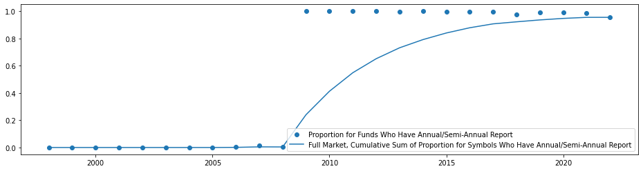

```python
csmar_fund_allocation['report_type_check'] = csmar_fund_allocation.Date.dt.year
report_type_check = csmar_fund_allocation.groupby(['MasterFundCode', 'report_type_check']).apply(lambda temp : 5 in temp.ReportTypeID.values or 6 in temp.ReportTypeID.values)
plt.figure(figsize=(16,4))
report_type_check_ = report_type_check.groupby(level=1).apply(lambda temp: temp.sum() / len(temp))
year_report_count = report_type_check.groupby(level=1).apply(lambda temp: temp.sum())
total_report_count = report_type_check.groupby(level=1).apply(lambda temp: len(temp))
plt.scatter(x=report_type_check_.index, y=report_type_check_.values, label='Proportion for Funds Who Have Annual/Semi-Annual Report')
temp = year_report_count.cumsum() / total_report_count.cumsum()
plt.plot(temp.index, temp.values, label='Full Market, Cumulative Sum of Proportion for Symbols Who Have Annual/Semi-Annual Report')
plt.legend()
pass
```

[figure not shown]

[中国证券监督管理委员会公告〔2008〕第4号](http://www.gov.cn/zwgk/2008-02/21/content_896020.htm)

使用存在二季度报/年报/半年报的数据

```python
csmar_fund_allocation = csmar_fund_allocation[csmar_fund_allocation.ReportTypeID.isin([2, 5, 6])]
csmar_fund_allocation = pd.merge(csmar_fund_allocation, csmar_symbol_code_mapping, on='MasterFundCode', how='left')
csmar_fund_allocation = csmar_fund_allocation[csmar_fund_allocation.Symbol.isin(main_data.index.get_level_values(0).unique())]
main_data = main_data.loc[csmar_fund_allocation.Symbol.unique(), slice(None)]
```

中国市场股票持股比例超过总管理规模30%

```python
filter_4 = csmar_fund_allocation[(csmar_fund_allocation.Equity / csmar_fund_allocation.TotalAsset) > .3]
co_index = np.intersect1d(filter_4.set_index(['Symbol', 'Date']).index, main_data.index)
main_data['filter_4'] = np.nan
main_data.loc[main_data.index.get_level_values(1).month == 6, 'filter_4'] = False
main_data.loc[co_index, 'filter_4'] = True
main_data = main_data.groupby(level=0).fillna(method='ffill').fillna(False)
main_data = main_data[main_data.filter_4].drop('filter_4', axis=1)
main_data
```

| Symbol | Date | operate_mode | underlying_asset_type | start_date |
| --- | --- | --- | --- | --- |
| 000001 | 2003-06 | 开放式基金 | 混合型 | 2001-12 |
|  | 2003-07 | 开放式基金 | 混合型 | 2001-12 |
|  | 2003-08 | 开放式基金 | 混合型 | 2001-12 |
|  | 2003-09 | 开放式基金 | 混合型 | 2001-12 |
|  | 2003-10 | 开放式基金 | 混合型 | 2001-12 |
| ... | ... | ... | ... | ... |
| 910028 | 2022-06 | 开放式基金 | 混合型 | 2021-06 |
|  | 2022-07 | 开放式基金 | 混合型 | 2021-06 |
|  | 2022-08 | 开放式基金 | 混合型 | 2021-06 |
|  | 2022-09 | 开放式基金 | 混合型 | 2021-06 |
|  | 2022-10 | 开放式基金 | 混合型 | 2021-06 |

215282 rows × 3 columns

```python
f'in view of all time span, filter 4: {record_shape} to {len(main_data.index.get_level_values(0).unique())}'
```

```
'in view of all time span, filter 4: 5916 to 4624'
```

### 4. full data

reset nav

```python
csmar_nav_monthly = pd.Series(csmar_nav_monthly.stack().swaplevel(), name='NAV')
csmar_nav_monthly = pd.DataFrame(csmar_nav_monthly).reset_index()
```

merge data

```python
main_data = pd.merge(main_data, csmar_nav_monthly, on=['Symbol', 'Date'], how='left').set_index(['Symbol', 'Date'])
main_data = pd.merge(main_data, csmar_fund_dividend, on=['Symbol', 'Date'], how='left').set_index(['Symbol', 'Date'])
main_data = pd.merge(main_data, csmar_fund_resolution, on=['Symbol', 'Date'], how='left').set_index(['Symbol', 'Date'])
```

handle NA

```python
main_data['NAV'] = main_data.groupby(level=0).apply(lambda x: x.NAV.fillna(method='ffill')).droplevel(0)
main_data['DividendperShare'] = main_data.DividendperShare.fillna(0)
main_data['SplitRatio'] = main_data.SplitRatio.fillna(1)
```

## **IV. Overall Performance**

### Return

$$ R_t^{real}=\frac{\left(NAV_t+Div_t\right)*SF_t}{NAV_{t-1}*SF_{t-1}}\tag{1} $$

$NAV_t$ 基金在 $t$ 月末的基金净值

$Div_t$ 在 $t$ 月中发放的现金分红

$SF_t$ 累计拆分因子

当$t$月中发生比例为$s_t$的拆分时, $SF_t=s_tSF_{t-1}$

公式等价于

$$ R_t^{real}=\frac{\left(NAV_t+Div_t\right)*s_t}{NAV_{t-1}}\tag{2} $$

#### 1. prepare

```python
import matplotlib.pyplot as plt
import numpy as np
import pandas as pd
import statsmodels.api as sm
from scipy import stats

from data.CSMAR.Fund_ShareChange import csmar_share_info
from data.JoinQuant.jq_all_fund_main_info import jq_all_fund_main_info
from data.SVC.svc_source import svc_source
from data.TwoStepData.csmar_nav_monthly import csmar_nav_monthly
from data.TwoStepData.main_data import main_data
from utils.functions import *
```

```python
main_data
```

| Symbol | Date | operate_mode | underlying_asset_type | start_date | NAV | DividendperShare | SplitRatio | NAV_shift | adj_factor | adj_NAV |
| --- | --- | --- | --- | --- | --- | --- | --- | --- | --- | --- |
| 000001 | 2003-06 | 开放式基金 | 混合型 | 2001-12 | 0.9730 | 0.033 | 1.0 | NaN | NaN | NaN |
|  | 2003-07 | 开放式基金 | 混合型 | 2001-12 | 0.9860 | 0.000 | 1.0 | 0.9730 | 1.0 | 0.9860 |
|  | 2003-08 | 开放式基金 | 混合型 | 2001-12 | 0.9540 | 0.000 | 1.0 | 0.9860 | 1.0 | 0.9540 |
|  | 2003-09 | 开放式基金 | 混合型 | 2001-12 | 0.9200 | 0.000 | 1.0 | 0.9540 | 1.0 | 0.9200 |
|  | 2003-10 | 开放式基金 | 混合型 | 2001-12 | 0.9360 | 0.000 | 1.0 | 0.9200 | 1.0 | 0.9360 |
| ... | ... | ... | ... | ... | ... | ... | ... | ... | ... | ... |
| 952009 | 2022-06 | 封闭式基金 | 混合型 | 2020-01 | 1.8868 | 0.000 | 1.0 | 1.7120 | 1.0 | 1.8868 |
|  | 2022-07 | 封闭式基金 | 混合型 | 2020-01 | 1.7885 | 0.000 | 1.0 | 1.8868 | 1.0 | 1.7885 |
|  | 2022-08 | 封闭式基金 | 混合型 | 2020-01 | 1.7257 | 0.000 | 1.0 | 1.7885 | 1.0 | 1.7257 |
|  | 2022-09 | 封闭式基金 | 混合型 | 2020-01 | 1.6665 | 0.000 | 1.0 | 1.7257 | 1.0 | 1.6665 |
|  | 2022-10 | 封闭式基金 | 混合型 | 2020-01 | 1.5892 | 0.000 | 1.0 | 1.6665 | 1.0 | 1.5892 |

240697 rows × 9 columns

NAV_shift calculation

```python
main_data['NAV_shift'] = main_data.groupby(level=0).apply(lambda x: x.NAV.shift(1)).droplevel(0)
```

split into stock fund and blend fund

apply formula

```python
blend_data = main_data[main_data.underlying_asset_type == '混合型']
stock_data = main_data[main_data.underlying_asset_type == '股票型']


return_of_csmar_stock_fund = stock_data.groupby(level=0).apply(lambda x: ((x.NAV + x.DividendperShare) * x.SplitRatio) / x.NAV_shift).droplevel(0)
return_of_csmar_blend_fund = blend_data.groupby(level=0).apply(lambda x: ((x.NAV + x.DividendperShare) * x.SplitRatio) / x.NAV_shift).droplevel(0)
return_of_all_fund = main_data.groupby(level=0).apply(lambda x: ((x.NAV + x.DividendperShare) * x.SplitRatio) / x.NAV_shift).droplevel(0)
```

market value weight generation

```python
MONTH_OF_YEAR = 6

csmar_share_info = csmar_share_info.drop_duplicates(subset=['Symbol', 'Date']).pivot(index='Date', columns='Symbol', values='EndDateShares')

csmar_share_info_yearly = csmar_share_info[csmar_share_info.index.month == MONTH_OF_YEAR]
csmar_nav_yearly = csmar_nav_monthly[csmar_nav_monthly.index.month == MONTH_OF_YEAR]

csmar_co_time_6 = np.intersect1d(csmar_share_info_yearly.index, csmar_nav_yearly.index)

csmar_blend_code_6 = np.intersect1d(csmar_nav_yearly.columns, jq_all_fund_main_info[jq_all_fund_main_info.underlying_asset_type == '混合型'].main_code.values)
csmar_blend_code_6 = np.intersect1d(csmar_blend_code_6, csmar_share_info_yearly.columns)

csmar_stock_code_6 = np.intersect1d(csmar_nav_yearly.columns, jq_all_fund_main_info[jq_all_fund_main_info.underlying_asset_type == '股票型'].main_code.values)
csmar_stock_code_6 = np.intersect1d(csmar_stock_code_6, csmar_share_info_yearly.columns)



csmar_stock_fund_weight_yearly = (csmar_share_info_yearly.loc[csmar_co_time_6, csmar_stock_code_6] * csmar_nav_yearly.loc[csmar_co_time_6, csmar_stock_code_6])

csmar_stock_fund_weight_yearly = pd.concat([csmar_stock_fund_weight_yearly, \
    pd.DataFrame([[np.nan] * csmar_stock_fund_weight_yearly.shape[1]], index=[pd.to_datetime('2023-06').to_period('M')], columns=csmar_stock_fund_weight_yearly.columns)])

csmar_stock_fund_weight_yearly = csmar_stock_fund_weight_yearly.resample('M').ffill()

stock_fund_dates = return_of_csmar_stock_fund.unstack(level=0).index
stock_fund_funds = return_of_csmar_stock_fund.unstack(level=0).columns

stock_fund_new = np.setdiff1d(stock_fund_funds, csmar_stock_fund_weight_yearly.columns)
print(f'{stock_fund_new} will not be used')

stock_fund_funds = np.intersect1d(stock_fund_funds, csmar_stock_fund_weight_yearly.columns)

csmar_stock_fund_weight_yearly = csmar_stock_fund_weight_yearly.loc[stock_fund_dates, stock_fund_funds]
csmar_stock_fund_weight_yearly = csmar_stock_fund_weight_yearly.div(csmar_stock_fund_weight_yearly.sum(axis=1), axis=0)
```

```
['007593' '007594'] will not be used
```

```python
csmar_blend_fund_weight_yearly = (csmar_share_info_yearly.loc[csmar_co_time_6, csmar_blend_code_6] * csmar_nav_yearly.loc[csmar_co_time_6, csmar_blend_code_6])
csmar_blend_fund_weight_yearly = pd.concat([csmar_blend_fund_weight_yearly, \
    pd.DataFrame([[np.nan] * csmar_blend_fund_weight_yearly.shape[1]], index=[pd.to_datetime('2023-06').to_period('M')], columns=csmar_blend_fund_weight_yearly.columns)])
csmar_blend_fund_weight_yearly = csmar_blend_fund_weight_yearly.resample('M').ffill()

blend_fund_dates = return_of_csmar_blend_fund.unstack(level=0).index
blend_fund_funds = return_of_csmar_blend_fund.unstack(level=0).columns

blend_fund_new = np.setdiff1d(blend_fund_funds, csmar_blend_fund_weight_yearly.columns)
print(f'{blend_fund_new} will not be used')
blend_fund_funds = np.intersect1d(blend_fund_funds, csmar_blend_fund_weight_yearly.columns)

csmar_blend_fund_weight_yearly = csmar_blend_fund_weight_yearly.loc[blend_fund_dates, blend_fund_funds]
csmar_blend_fund_weight_yearly = csmar_blend_fund_weight_yearly.div(csmar_blend_fund_weight_yearly.sum(axis=1), axis=0)
```

```
['004112' '004212' '004783' '005392' '009911' '010398' '010399' '519610'
 '519611' '519612' '960002' '960004'] will not be used
```

#### 2. analysis

use data later than 2005-06

```python
return_of_csmar_stock_fund.unstack(level=0)
```

| Symbol Date | 000042 | 000059 | 000082 | 000176 | 000309 | 000311 | 000312 | 000313 | 000326 | 000368 | ... | 660011 | 671030 | 673090 | 673100 | 673101 | 690008 | 700002 | 740101 | 960000 | 960022 |
| --- | --- | --- | --- | --- | --- | --- | --- | --- | --- | --- | --- | --- | --- | --- | --- | --- | --- | --- | --- | --- | --- |
| 2004-06 | NaN | NaN | NaN | NaN | NaN | NaN | NaN | NaN | NaN | NaN | ... | NaN | NaN | NaN | NaN | NaN | NaN | NaN | NaN | NaN | NaN |
| 2004-07 | NaN | NaN | NaN | NaN | NaN | NaN | NaN | NaN | NaN | NaN | ... | NaN | NaN | NaN | NaN | NaN | NaN | NaN | NaN | NaN | NaN |
| 2004-08 | NaN | NaN | NaN | NaN | NaN | NaN | NaN | NaN | NaN | NaN | ... | NaN | NaN | NaN | NaN | NaN | NaN | NaN | NaN | NaN | NaN |
| 2004-09 | NaN | NaN | NaN | NaN | NaN | NaN | NaN | NaN | NaN | NaN | ... | NaN | NaN | NaN | NaN | NaN | NaN | NaN | NaN | NaN | NaN |
| 2004-10 | NaN | NaN | NaN | NaN | NaN | NaN | NaN | NaN | NaN | NaN | ... | NaN | NaN | NaN | NaN | NaN | NaN | NaN | NaN | NaN | NaN |
| ... | ... | ... | ... | ... | ... | ... | ... | ... | ... | ... | ... | ... | ... | ... | ... | ... | ... | ... | ... | ... | ... |
| 2022-06 | 1.083720 | 1.093872 | 1.097926 | 1.108846 | 1.162114 | 1.099558 | 1.119288 | 1.118925 | 1.121493 | 1.075491 | ... | 1.073979 | 1.186415 | 1.074244 | 1.107217 | 1.106920 | 1.073746 | 1.108399 | 1.108128 | 1.077097 | NaN |
| 2022-07 | 0.948945 | 0.927085 | 0.957503 | 0.934405 | 1.009198 | 0.938431 | 0.939431 | 0.939095 | 0.964950 | 0.943766 | ... | 0.979501 | 0.951419 | 0.950455 | 0.940773 | 0.940471 | 0.967033 | 0.946249 | 0.946837 | 0.934307 | NaN |
| 2022-08 | 0.982664 | 0.982851 | 0.981370 | 0.989452 | 0.927342 | 0.993568 | 0.983288 | 0.982950 | 0.977824 | 0.994084 | ... | 0.980644 | 0.978594 | 0.958385 | 0.982208 | 0.981824 | 0.989583 | 0.967653 | 0.972281 | 0.978288 | NaN |
| 2022-09 | 0.933691 | 0.947017 | 0.948632 | 0.931608 | 0.888343 | 0.946051 | 0.940035 | 0.939722 | 0.935495 | 0.942303 | ... | 0.931428 | 0.940867 | 0.916487 | 0.929517 | 0.929184 | 0.950239 | 0.928659 | 0.929094 | 0.950322 | NaN |
| 2022-10 | 0.953504 | 1.084306 | 0.951148 | 0.930670 | 1.017517 | 0.911040 | 0.920019 | 0.919743 | 0.976210 | 0.923256 | ... | 1.013761 | 0.892398 | 1.008692 | 0.929107 | 0.928847 | 0.944612 | 0.962687 | 0.930763 | 0.929635 | NaN |

221 rows × 1247 columns

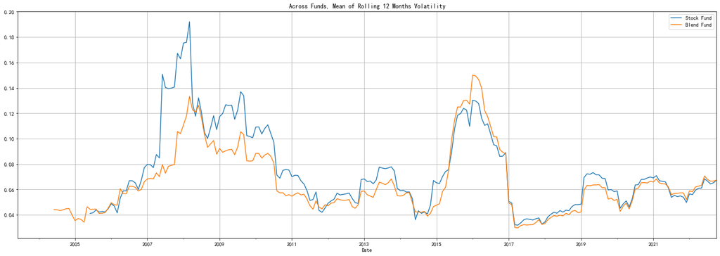

```python
plt.figure(figsize=(24, 8))
rolling_months = 12
(return_of_csmar_stock_fund.unstack(level=0) - 1).rolling(rolling_months).std().mean(axis=1).plot(label='Stock Fund')
(return_of_csmar_blend_fund.unstack(level=0) - 1).rolling(rolling_months).std().mean(axis=1).plot(label='Blend Fund')
plt.grid()
plt.legend()
plt.title(f'Across Funds, Mean of Rolling {rolling_months} Months Volatility')
```

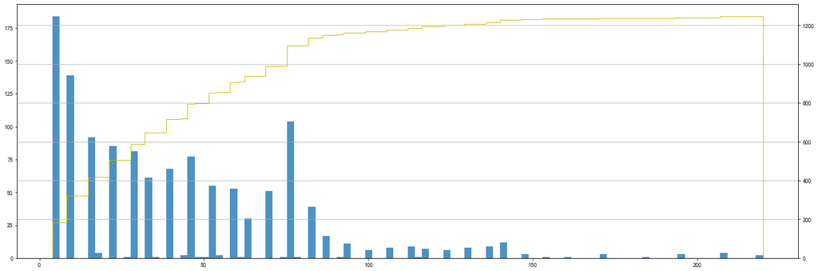

```python
fig, ax = plt.subplots(figsize=(24, 8))
return_of_csmar_stock_fund.unstack(level=0).describe().loc['count'].hist(bins=100, ax=ax, alpha=.8)
ax.grid(False)
ax1 = ax.twinx()
return_of_csmar_stock_fund.unstack(level=0).describe().loc['count'].hist(bins=100, cumulative=True, histtype='step', ax=ax1, color='y')
```

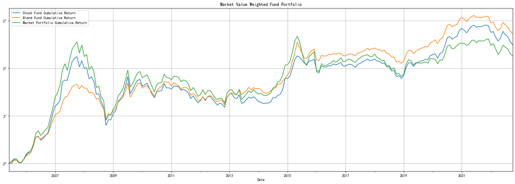

```python
plt.figure(figsize=(24,8))

(((return_of_csmar_stock_fund.unstack(level=0) - 1) * csmar_stock_fund_weight_yearly).sum(axis=1) + 1).loc['2005-6':].cumprod().plot(label='Stock Fund Cumulative Return')
(((return_of_csmar_blend_fund.unstack(level=0) - 1) * csmar_blend_fund_weight_yearly).sum(axis=1) + 1).loc['2005-6':].cumprod().plot(label='Blend Fund Cumulative Return')
((svc_source.loc['2005-6': ].mktrf + svc_source.loc['2005-6': ].rf) + 1).cumprod().plot(label='Market Portfolio Cumulative Return')

plt.yscale('log', base=2)
plt.title('Market Value Weighted Fund Portfolio')
plt.grid()
plt.legend()
plt.show()
```

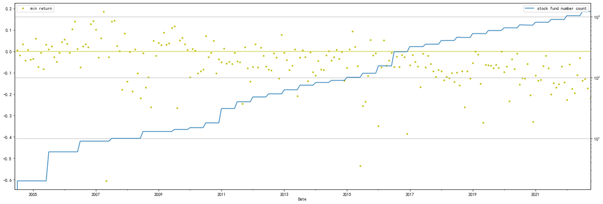

```python
fig, ax1 = plt.subplots()
fig.set_figheight(8)
fig.set_figwidth(24)
(return_of_csmar_stock_fund.unstack(0) - 1).T.describe().loc['min'].plot(ax=ax1, style='.', label='min return', color='y')
ax1.legend()
ax1.legend(loc='upper left')
ax1.axhline(color='y', alpha=.7)
ax2 = ax1.twinx()
(return_of_csmar_stock_fund.unstack(0) - 1).T.describe().loc['count'].plot(ax=ax2, label='stock fund number count')
ax2.grid()
ax2.set_yscale('log')
ax2.legend(loc='upper right')
```

```python
# plt.figure(figsize=(24,8))
# return_of_stock_fund.groupby(level=1).mean().loc['2005-6':].cumprod().plot(label='Stock Fund Cumulative Return')
# return_of_blend_fund.groupby(level=1).mean().loc['2005-6':].cumprod().plot(label='Blend Fund Cumulative Return')
# plt.yscale('log', base=2)
# plt.title('1/N Weighted Fund Portfolio')
# plt.grid()
# plt.legend()
```

why use data later than 2005-06?

```python
co_time = np.intersect1d(csmar_share_info.index, csmar_nav_monthly.index)
co_stocks = np.intersect1d(csmar_share_info.columns, csmar_nav_monthly.columns)
compare_share_info = csmar_share_info.loc[co_time, co_stocks]
compare_nav_monthly = csmar_nav_monthly.loc[co_time, co_stocks]
```

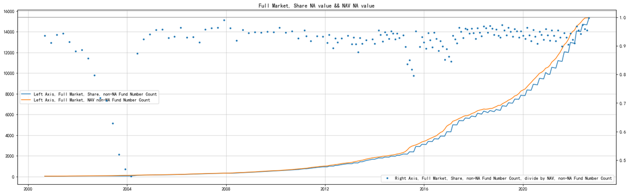

```python
filled_share_info = compare_share_info.fillna(method='ffill')
fig, ax1 = plt.subplots()
fig.set_figheight(8)
fig.set_figwidth(24)
def na_compare(row):
    date = row.name
    available_funds = row.dropna().index
    selected_share_info = (row * filled_share_info.loc[date]).dropna()
    available_share_funds = selected_share_info.index

    return [len(available_share_funds), len(available_funds)]

temp = np.array(list(compare_nav_monthly.apply(na_compare, axis=1).values))
ax1.plot(compare_nav_monthly.index.astype(np.datetime64), temp[:, 0], label='Left Axis, Full Market, Share, non-NA Fund Number Count')
ax1.plot(compare_nav_monthly.index.astype(np.datetime64), temp[:, 1], label='Left Axis, Full Market, NAV non-NA Fund Number Count')
ax1.legend(loc='center left')
ax1.grid(linewidth=.5)

ax2 = ax1.twinx()

pd.Series(temp[:, 0] / temp[:, 1] ,index=compare_nav_monthly.index.astype(np.datetime64)).plot(style='.', label='Right Axis, Full Market, Share, non-NA Fund Number Count, divide by NAV, non-NA Fund Number Count')
plt.title('Full Market, Share NA value && NAV NA value')
ax2.legend(loc='lower right')

ax2.axhline(y=1, color='grey', alpha=.7)
```

Size effect in fund?

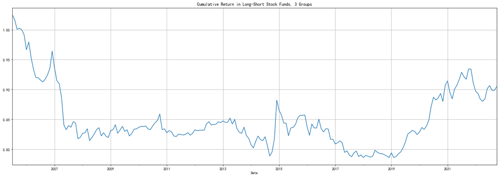

```python
stock_fund_weight_ = (csmar_share_info_yearly.loc[csmar_co_time_6, csmar_stock_code_6] * csmar_nav_yearly.loc[csmar_co_time_6, csmar_stock_code_6])
stock_fund_weight_ = pd.concat([stock_fund_weight_, \
    pd.DataFrame([[np.nan] * stock_fund_weight_.shape[1]], index=[pd.to_datetime('2023-06').to_period('M')], columns=stock_fund_weight_.columns)])
stock_fund_weight_ = stock_fund_weight_.resample('M').ffill()

groups = 3
ret_stock_fund = return_of_csmar_stock_fund.unstack(0) - 1
stock_fund_groups = stock_fund_weight_.dropna(how='all').apply(lambda x: pd.qcut(x, groups, labels=np.arange(groups)) if not pd.isna(x).all() else x, axis=1)
co_time = np.intersect1d(stock_fund_groups.index, ret_stock_fund.index)
co_stocks = np.intersect1d(stock_fund_groups.columns, ret_stock_fund.columns)

stock_fund_groups = stock_fund_groups.loc[co_time, co_stocks]
ret_stock_fund = ret_stock_fund.loc[co_time, co_stocks]

def func(x):
    date = x.name
    result = pd.DataFrame([x, stock_fund_groups.loc[date]], index=['return', 'rank']).T.groupby('rank').mean().iloc[:, 0]
    if result.shape[0] < groups:

        return pd.Series([np.nan] * groups, name=date)
    else:
        return result

stock_grouped_return = ret_stock_fund.apply(func, axis=1).dropna()
plt.figure(figsize=(24, 8))
plt.title(f'Cumulative Return in Long-Short Stock Funds, {groups} Groups')
(stock_grouped_return.iloc[:, -1] - stock_grouped_return.iloc[:, 0] + 1).cumprod().plot()
plt.grid()
```

```python
stats.ttest_1samp((stock_grouped_return.iloc[:, -1] - stock_grouped_return.iloc[:, 0]).dropna(), 0, alternative ='greater')
```

```
Ttest_1sampResult(statistic=-0.4280697831117795, pvalue=0.6654773213617575)
```

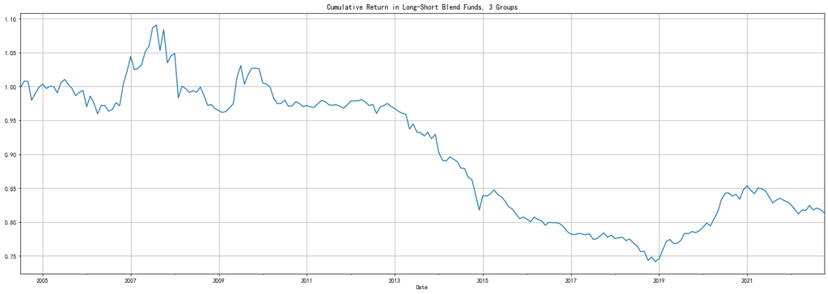

```python
blend_fund_weight_ = (csmar_share_info_yearly.loc[csmar_co_time_6, csmar_blend_code_6] * csmar_nav_yearly.loc[csmar_co_time_6, csmar_blend_code_6])
blend_fund_weight_ = pd.concat([blend_fund_weight_, \
    pd.DataFrame([[np.nan] * blend_fund_weight_.shape[1]], index=[pd.to_datetime('2023-06').to_period('M')], columns=blend_fund_weight_.columns)])
blend_fund_weight_ = blend_fund_weight_.resample('M').ffill()

groups = 3
ret_blend_fund = return_of_csmar_blend_fund.unstack(0) - 1
blend_fund_groups = blend_fund_weight_.dropna(how='all').apply(lambda x: pd.qcut(x, groups, labels=np.arange(groups)) if not pd.isna(x).all() else x, axis=1)
co_time = np.intersect1d(blend_fund_groups.index, ret_blend_fund.index)
co_stocks = np.intersect1d(blend_fund_groups.columns, ret_blend_fund.columns)

blend_fund_groups = blend_fund_groups.loc[co_time, co_stocks]
ret_blend_fund = ret_blend_fund.loc[co_time, co_stocks]

def func(x):
    date = x.name
    result = pd.DataFrame([x, blend_fund_groups.loc[date]], index=['return', 'rank']).T.groupby('rank').mean().iloc[:, 0]
    if result.shape[0] < groups:

        return pd.Series([np.nan] * groups, name=date)
    else:
        return result
plt.figure(figsize=(24, 8))
plt.title(f'Cumulative Return in Long-Short Blend Funds, {groups} Groups')
blend_grouped_return = ret_blend_fund.apply(func, axis=1).dropna()

(blend_grouped_return.iloc[:, -1] - blend_grouped_return.iloc[:, 0] + 1).cumprod().plot()
plt.grid()
```

```python
stats.ttest_1samp((blend_grouped_return.iloc[:, -1] - blend_grouped_return.iloc[:, 0]).dropna(), 0, alternative ='greater')
```

```
Ttest_1sampResult(statistic=-1.1071280457833819, pvalue=0.8652734362722437)
```

### Regression

```python
import pandas as pd
import statsmodels.api as sm
from utils.functions import *

from data.SVC.svc_source import svc_source
from data.TwoStepData.csmar_blend_fund_weight_yearly import csmar_blend_fund_weight_yearly
from data.TwoStepData.csmar_stock_fund_weight_yearly import csmar_stock_fund_weight_yearly
from data.TwoStepData.return_of_csmar_blend_fund import return_of_csmar_blend_fund
from data.TwoStepData.return_of_csmar_stock_fund import return_of_csmar_stock_fund
```

regression table construction

```python
stock_fund_regression = (return_of_csmar_stock_fund.unstack(level=0) * csmar_stock_fund_weight_yearly).sum(axis=1).sort_index()
stock_fund_regression.name = 'stock_fund'

blend_fund_regression = (return_of_csmar_blend_fund.unstack(level=0) * csmar_blend_fund_weight_yearly).sum(axis=1).sort_index()
blend_fund_regression.name = 'blend_fund'


regression_source = pd.merge(stock_fund_regression, svc_source[['mktrf', 'rf', 'smb', 'vmg']], on='Date')
regression_source = pd.merge(regression_source, blend_fund_regression, on='Date')

regression_source['α'] = 1

regression_source = regression_source.loc['2005-6':]
regression_source
```

| Date | stock_fund | mktrf | rf | smb | vmg | blend_fund | α |
| --- | --- | --- | --- | --- | --- | --- | --- |
| 2005-06 | 0.006722 | 0.011522 | 0.001856 | 0.000517 | 0.056121 | 0.006373 | 1 |
| 2005-07 | 0.004098 | -0.019041 | 0.001856 | -0.051082 | 0.071114 | 0.004433 | 1 |
| 2005-08 | 0.030586 | 0.071589 | 0.001856 | 0.094712 | -0.049516 | 0.021039 | 1 |
| 2005-09 | -0.016050 | 0.001288 | 0.001856 | 0.033242 | 0.045120 | 0.001628 | 1 |
| 2005-10 | -0.034043 | -0.054595 | 0.001856 | -0.001480 | 0.024557 | -0.023213 | 1 |
| ... | ... | ... | ... | ... | ... | ... | ... |
| 2022-06 | 0.101756 | 0.088114 | 0.001241 | -0.020506 | -0.028009 | 0.086277 | 1 |
| 2022-07 | -0.042236 | -0.030989 | 0.001241 | 0.071198 | -0.005291 | -0.031624 | 1 |
| 2022-08 | -0.028712 | -0.025324 | 0.001241 | -0.012092 | 0.025149 | -0.028365 | 1 |
| 2022-09 | -0.065936 | -0.067855 | 0.001241 | -0.028691 | 0.018830 | -0.059834 | 1 |
| 2022-10 | -0.051091 | -0.035392 | 0.001241 | 0.074949 | -0.034494 | -0.039352 | 1 |

209 rows × 7 columns

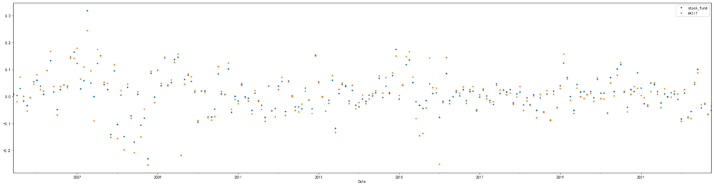

```python
regression_source[['stock_fund', 'mktrf']].plot(style='.', figsize=(32, 8))
```

naïve regression

```python
stock_naïve = sm.OLS(regression_source.stock_fund, regression_source[['α']]).fit()
blend_naïve = sm.OLS(regression_source.blend_fund, regression_source[['α']]).fit()
stock_naïve_excess = sm.OLS(regression_source.stock_fund - regression_source.rf, regression_source[['α']]).fit()
blend_naïve_excess = sm.OLS(regression_source.blend_fund - regression_source.rf, regression_source[['α']]).fit()
```

```python
pd.DataFrame(
[
[float_to_percent(stock_naïve.params[0]), stock_naïve.tvalues.iloc[0].round(3), stock_naïve.pvalues[0].round(3), yearly_return(stock_naïve.params[0])],
[float_to_percent(blend_naïve.params[0]), blend_naïve.tvalues.iloc[0].round(3), blend_naïve.pvalues[0].round(3), yearly_return(blend_naïve.params[0])],
[float_to_percent(stock_naïve_excess.params[0]), stock_naïve_excess.tvalues.iloc[0].round(3), stock_naïve_excess.pvalues[0].round(3), yearly_return(stock_naïve_excess.params[0])],
[float_to_percent(blend_naïve_excess.params[0]), blend_naïve_excess.tvalues.iloc[0].round(3), blend_naïve_excess.pvalues[0].round(3), yearly_return(blend_naïve_excess.params[0])],
],
index=['stock_naïve', 'blend_naïve', 'stock_naïve_excess', 'blend_naïve_excess'], columns=pd.Series(['α', 't', 'p', 'annual α'],\
name=f'{regression_source.index[0].year}/{regression_source.index[0].month}-{regression_source.index[-1].year}/{regression_source.index[-1].month}'))
```

| 2005/6-2022/10 | α | t | p | annual α |
| --- | --- | --- | --- | --- |
| stock_naïve | 1.102% | 2.377 | 0.018 | 14.05% |
| blend_naïve | 1.057% | 2.884 | 0.004 | 13.45% |
| stock_naïve_excess | 0.912% | 1.966 | 0.051 | 11.51% |
| blend_naïve_excess | 0.867% | 2.364 | 0.019 | 10.91% |

CAPM regression

```python
stock_capm = sm.OLS(regression_source.stock_fund - regression_source.rf, regression_source[['α', 'mktrf']]).fit()
blend_capm = sm.OLS(regression_source.blend_fund - regression_source.rf, regression_source[['α', 'mktrf']]).fit()
```

```python
pd.DataFrame(
[
[float_to_percent(stock_capm.params[0]) + ' (' + str(stock_capm.tvalues.iloc[0].round(3)) + ')', \
    str(stock_capm.params[1].round(3)) + ' (' + str(stock_capm.tvalues.iloc[1].round(3)) + ')',\
         stock_capm.rsquared, yearly_return(stock_capm.params[0])],
[float_to_percent(blend_capm.params[0]) + ' (' + str(blend_capm.tvalues.iloc[0].round(3)) + ')', \
    str(blend_capm.params[1].round(3)) + ' (' + str(blend_capm.tvalues.iloc[1].round(3)) + ')', \
        blend_capm.rsquared, yearly_return(blend_capm.params[0])],
],
columns=['α', 'mktrf', 'r^2', 'annual α'], index=pd.Series(['stock_capm', 'blend_capm'], \
name=f'{regression_source.index[0].year}/{regression_source.index[0].month}-{regression_source.index[-1].year}/{regression_source.index[-1].month}')).T
```

| 2005/6-2022/10 | stock_capm | blend_capm |
| --- | --- | --- |
| α | 0.207% (1.336) | 0.329% (2.154) |
| mktrf | 0.812 (40.996) | 0.62 (31.741) |
| r^2 | 0.890342 | 0.829554 |
| annual α | 2.51% | 4.02% |

SVC regression

```python
stock_svc = sm.OLS(regression_source.stock_fund - regression_source.rf, regression_source[['α', 'mktrf', 'smb', 'vmg']]).fit()
blend_svc = sm.OLS(regression_source.blend_fund - regression_source.rf, regression_source[['α', 'mktrf', 'smb', 'vmg']]).fit()
```

```python
pd.DataFrame(
[
[float_to_percent(stock_svc.params[0]) + ' (' + str(stock_svc.tvalues.iloc[0].round(3)) + ')', \
    str(stock_svc.params[1].round(3)) + ' (' + str(stock_svc.tvalues.iloc[1].round(3)) + ')', \
        str(stock_svc.params[2].round(3)) + ' (' + str(stock_svc.tvalues.iloc[2].round(3)) + ')', \
            str(stock_svc.params[3].round(3)) + ' (' + str(stock_svc.tvalues.iloc[3].round(3)) + ')', \
                stock_svc.rsquared, yearly_return(stock_svc.params[0])],
[float_to_percent(blend_svc.params[0]) + ' (' + str(blend_svc.tvalues.iloc[0].round(3)) + ')', \
    str(blend_svc.params[1].round(3)) + ' (' + str(blend_svc.tvalues.iloc[1].round(3)) + ')', \
        str(blend_svc.params[2].round(3)) + ' (' + str(blend_svc.tvalues.iloc[2].round(3)) + ')', \
            str(blend_svc.params[3].round(3)) + ' (' + str(blend_svc.tvalues.iloc[3].round(3)) + ')', \
                blend_svc.rsquared, yearly_return(blend_svc.params[0])],
],

columns=['α', 'mktrf', 'smb', 'vmg', 'r^2', 'annual α'], index=pd.Series(['stock_svc', 'blend_svc'], \
name=f'{regression_source.index[0].year}/{regression_source.index[0].month}-{regression_source.index[-1].year}/{regression_source.index[-1].month}')).T
```

| 2005/6-2022/10 | stock_svc | blend_svc |
| --- | --- | --- |
| α | 0.382% (2.397) | 0.64% (4.05) |
| mktrf | 0.825 (43.267) | 0.594 (31.388) |
| smb | -0.183 (-5.328) | -0.052 (-1.529) |
| vmg | -0.023 (-0.504) | -0.244 (-5.448) |
| r^2 | 0.906085 | 0.852232 |
| annual α | 4.68% | 7.96% |

## **V. Fund Evaluation**

```python
import datetime
import pandas as pd
import numpy as np
from factors import *
from pandarallel import pandarallel
start_time = '2005-6'
end_time = (datetime.datetime.now() - pd.offsets.MonthEnd(1)).strftime('%Y-%m')
pandarallel.initialize()
```

[output not shown]

### CAPM α +

```python
from factors import *

@fund_ended_check
@cache_wrapper(expire= 60 * 60 * 24 * 30)
def capm_α_generation(x):
    from sklearn.linear_model import LinearRegression
    from data.TwoStepData.regression_source import regression_source
    x = x.dropna()
    temp_dates = x.index
    temp_regression = regression_source.loc[temp_dates]
    α = LinearRegression().fit(X = temp_regression.mktrf.values.reshape(-1, 1), y = (x - temp_regression.rf).values).intercept_
    return α

all_fund_capm_α = return_of_all_fund_.loc[start_time: end_time].rolling(window = 36, min_periods = 36 - MAX_NA_NUM).parallel_apply(capm_α_generation)
all_fund_capm_α.shape
```

```
(209, 4624)
```

```python
group_and_statistic(all_fund_capm_α, groups=5, weighting='mkt', interval=1, kind='all_time_span', time_span=24)
```

|  |  | group0 | group1 | group2 | group3 | group4 | long-short |
| --- | --- | --- | --- | --- | --- | --- | --- |
| excess | α (monthly) | 1.014% | 1.047% | 1.103% | 1.239% | 1.236% | 0.222% |
|  | annual α | 12.87% | 13.31% | 14.07% | 15.93% | 15.89% | 2.7% |
|  | t | 2.087 | 2.17 | 2.288 | 2.519 | 2.403 | 1.341 |
|  | R^2 | 0.0 | -0.0 | 0.0 | 0.0 | -0.0 | 0.0 |
|  | Obs | 207 | 207 | 207 | 207 | 207 | 207 |
| capm α | α (monthly) | 0.25% | 0.295% | 0.36% | 0.527% | 0.484% | 0.234% |
|  | annual α | 3.05% | 3.6% | 4.4% | 6.51% | 5.97% | 2.84% |
|  | t | 1.887 | 2.036 | 2.251 | 2.295 | 2.093 | 1.4 |
|  | R^2 | 0.927 | 0.911 | 0.892 | 0.786 | 0.801 | 0.002 |
|  | Obs | 207 | 207 | 207 | 207 | 207 | 207 |
| svc α | α (monthly) | 0.426% | 0.551% | 0.689% | 0.807% | 0.996% | 0.57% |
|  | annual α | 5.23% | 6.82% | 8.58% | 10.13% | 12.63% | 7.06% |
|  | t | 2.974 | 3.57 | 4.165 | 3.231 | 4.282 | 3.36 |
|  | R^2 | 0.931 | 0.918 | 0.906 | 0.794 | 0.837 | 0.162 |
|  | Obs | 207 | 207 | 207 | 207 | 207 | 207 |

```python
group_and_statistic(all_fund_capm_α, groups = 5, weighting = 'mkt', interval = 1, kind = 'time_series_subsample', time_span = 24)
```

|  |  | 2005-06/2007-07 | 2007-08/2009-09 | 2009-10/2011-11 | 2011-12/2014-01 | 2014-02/2016-03 | 2016-04/2018-05 | 2018-06/2020-07 | 2020-08/2022-08 |
| --- | --- | --- | --- | --- | --- | --- | --- | --- | --- |
| excess | α (monthly) | -0.42% | 0.126% | 0.333% | 0.648% | 0.134% | 0.769% | 0.189% | -0.01% |
|  | annual α | -4.93% | 1.52% | 4.06% | 8.06% | 1.62% | 9.63% | 2.29% | -0.12% |
|  | t | -0.844 | 0.412 | 0.733 | 1.956 | 0.168 | 2.734 | 0.634 | -0.017 |
|  | R^2 | 0.0 | 0.0 | 0.0 | 0.0 | 0.0 | 0.0 | 0.0 | 0.0 |
|  | Obs | 26 | 26 | 26 | 26 | 26 | 26 | 26 | 25 |
| capm α | α (monthly) | 0.463% | 0.078% | 0.205% | 0.65% | -0.161% | 0.774% | 0.223% | 0.094% |
|  | annual α | 5.7% | 0.94% | 2.49% | 8.08% | -1.92% | 9.7% | 2.71% | 1.13% |
|  | t | 0.782 | 0.266 | 0.458 | 1.923 | -0.21 | 2.71 | 0.718 | 0.169 |
|  | R^2 | 0.188 | 0.129 | 0.096 | 0.003 | 0.146 | 0.011 | 0.01 | 0.099 |
|  | Obs | 26 | 26 | 26 | 26 | 26 | 26 | 26 | 25 |
| svc α | α (monthly) | 0.804% | 0.333% | 0.156% | 1.225% | -0.123% | 0.155% | 0.102% | 0.554% |
|  | annual α | 10.09% | 4.08% | 1.89% | 15.74% | -1.47% | 1.87% | 1.24% | 6.85% |
|  | t | 1.067 | 1.17 | 0.353 | 4.055 | -0.234 | 0.642 | 0.336 | 1.346 |
|  | R^2 | 0.226 | 0.341 | 0.56 | 0.527 | 0.796 | 0.568 | 0.163 | 0.571 |
|  | Obs | 26 | 26 | 26 | 26 | 26 | 26 | 26 | 25 |

```python
group_and_statistic(all_fund_capm_α, groups = 5, weighting = 'mkt', interval = 1, kind = 'time_series_rolling', time_span = 24)
```

|  |  | 2005-06/2007-06 | 2006-06/2008-06 | 2007-06/2009-06 | 2008-06/2010-06 | 2009-06/2011-06 | 2010-06/2012-06 | 2011-06/2013-06 | 2012-06/2014-06 | 2013-06/2015-06 | 2014-06/2016-06 | 2015-06/2017-06 | 2016-06/2018-06 | 2017-06/2019-06 | 2018-06/2020-06 | 2019-06/2021-06 | 2020-06/2022-06 | 2021-06/2023-06 | 2022-06/2024-06 |
| --- | --- | --- | --- | --- | --- | --- | --- | --- | --- | --- | --- | --- | --- | --- | --- | --- | --- | --- | --- |
| excess | α (monthly) | -0.507% | -0.624% | -0.012% | 0.22% | 0.336% | 0.178% | 0.556% | 0.45% | 0.384% | 0.23% | 0.329% | 0.758% | 0.489% | 0.277% | 0.369% | -0.03% | -0.311% | 0.111% |
|  | annual α | -5.92% | -7.24% | -0.15% | 2.67% | 4.11% | 2.15% | 6.88% | 5.53% | 4.7% | 2.8% | 4.02% | 9.49% | 6.02% | 3.38% | 4.52% | -0.36% | -3.67% | 1.34% |
|  | t | -0.994 | -1.243 | -0.027 | 0.795 | 0.702 | 0.385 | 2.12 | 1.19 | 0.46 | 0.28 | 0.965 | 2.553 | 1.377 | 0.933 | 0.777 | -0.054 | -0.485 | 0.081 |
|  | R^2 | 0.0 | -0.0 | 0.0 | -0.0 | 0.0 | -0.0 | 0.0 | -0.0 | 0.0 | -0.0 | 0.0 | 0.0 | 0.0 | -0.0 | 0.0 | 0.0 | 0.0 | 0.0 |
|  | Obs | 25 | 25 | 25 | 25 | 25 | 25 | 25 | 25 | 25 | 25 | 25 | 25 | 25 | 25 | 25 | 25 | 15 | 3 |
| capm α | α (monthly) | 0.443% | -0.229% | 0.039% | 0.236% | 0.337% | 0.12% | 0.539% | 0.45% | -0.082% | -0.09% | 0.429% | 0.766% | 0.487% | 0.307% | 0.319% | -0.089% | -0.084% | -0.882% |
|  | annual α | 5.44% | -2.71% | 0.47% | 2.87% | 4.12% | 1.45% | 6.67% | 5.54% | -0.98% | -1.07% | 5.27% | 9.59% | 6.0% | 3.75% | 3.89% | -1.07% | -1.0% | -10.09% |
|  | t | 0.767 | -0.556 | 0.099 | 0.857 | 0.69 | 0.267 | 1.989 | 1.165 | -0.093 | -0.113 | 1.676 | 2.534 | 1.343 | 0.995 | 0.636 | -0.159 | -0.131 | -0.196 |
|  | R^2 | 0.237 | 0.395 | 0.28 | 0.051 | 0.002 | 0.1 | 0.006 | 0.0 | 0.082 | 0.139 | 0.465 | 0.01 | 0.001 | 0.01 | 0.006 | 0.061 | 0.135 | 0.055 |
|  | Obs | 25 | 25 | 25 | 25 | 25 | 25 | 25 | 25 | 25 | 25 | 25 | 25 | 25 | 25 | 25 | 25 | 15 | 3 |
| svc α | α (monthly) | 0.723% | 0.078% | 0.22% | 0.585% | 0.506% | 0.359% | 0.771% | 1.063% | 0.167% | 0.099% | -0.113% | 0.126% | 0.02% | 0.183% | 0.245% | 0.497% | -0.017% | -2.962% |
|  | annual α | 9.03% | 0.94% | 2.67% | 7.25% | 6.24% | 4.4% | 9.65% | 13.53% | 2.03% | 1.19% | -1.35% | 1.52% | 0.23% | 2.22% | 2.98% | 6.13% | -0.21% | -30.29% |
|  | t | 0.967 | 0.168 | 0.543 | 2.274 | 1.037 | 0.861 | 2.454 | 3.411 | 0.317 | 0.16 | -0.27 | 0.476 | 0.078 | 0.603 | 0.664 | 1.191 | -0.032 | -0.0 |
|  | R^2 | 0.256 | 0.463 | 0.363 | 0.403 | 0.339 | 0.611 | 0.382 | 0.618 | 0.809 | 0.783 | 0.525 | 0.542 | 0.616 | 0.161 | 0.513 | 0.567 | 0.63 | 1.0 |
|  | Obs | 25 | 25 | 25 | 25 | 25 | 25 | 25 | 25 | 25 | 25 | 25 | 25 | 25 | 25 | 25 | 25 | 15 | 3 |

### SVC α +

```python
from factors import *

@fund_ended_check
@cache_wrapper(expire= 60 * 60 * 24 * 30)
def svc_α_generation(x):
    from sklearn.linear_model import LinearRegression
    from data.TwoStepData.regression_source import regression_source
    x = x.dropna()
    temp_dates = x.index
    temp_regression = regression_source.loc[temp_dates]
    α = LinearRegression().fit(X = temp_regression[['mktrf', 'smb', 'vmg']].values, y = (x - temp_regression.rf).values).intercept_
    return α

all_fund_svc_α = return_of_all_fund_.loc[start_time: end_time].rolling(window = 36, min_periods = 36 - MAX_NA_NUM).parallel_apply(svc_α_generation)

all_fund_svc_α.shape
```

```
(209, 4624)
```

```python
group_and_statistic(all_fund_svc_α, groups=5, weighting='mkt', interval=1, kind='all_time_span')
```

|  |  | group0 | group1 | group2 | group3 | group4 | long-short |
| --- | --- | --- | --- | --- | --- | --- | --- |
| excess | α (monthly) | 0.947% | 1.041% | 1.123% | 1.284% | 1.252% | 0.305% |
|  | annual α | 11.97% | 13.23% | 14.34% | 16.54% | 16.1% | 3.72% |
|  | t | 1.937 | 2.162 | 2.355 | 2.514 | 2.467 | 1.933 |
|  | R^2 | 0.0 | 0.0 | 0.0 | 0.0 | -0.0 | -0.0 |
|  | Obs | 207 | 207 | 207 | 207 | 207 | 207 |
| capm α | α (monthly) | 0.179% | 0.287% | 0.387% | 0.566% | 0.504% | 0.324% |
|  | annual α | 2.17% | 3.5% | 4.74% | 7.01% | 6.21% | 3.96% |
|  | t | 1.329 | 2.079 | 2.464 | 2.159 | 2.29 | 2.042 |
|  | R^2 | 0.925 | 0.919 | 0.893 | 0.741 | 0.815 | 0.006 |
|  | Obs | 207 | 207 | 207 | 207 | 207 | 207 |
| svc α | α (monthly) | 0.232% | 0.489% | 0.688% | 0.895% | 1.072% | 0.84% |
|  | annual α | 2.82% | 6.02% | 8.58% | 11.29% | 13.65% | 10.56% |
|  | t | 1.554 | 3.284 | 4.191 | 3.137 | 4.973 | 5.898 |
|  | R^2 | 0.925 | 0.924 | 0.905 | 0.751 | 0.856 | 0.35 |
|  | Obs | 207 | 207 | 207 | 207 | 207 | 207 |

```python
group_and_statistic(all_fund_svc_α, groups = 5, weighting = 'mkt', interval = 1, kind = 'time_series_subsample', time_span = 24)
```

|  |  | 2005-06/2007-07 | 2007-08/2009-09 | 2009-10/2011-11 | 2011-12/2014-01 | 2014-02/2016-03 | 2016-04/2018-05 | 2018-06/2020-07 | 2020-08/2022-08 |
| --- | --- | --- | --- | --- | --- | --- | --- | --- | --- |
| excess | α (monthly) | -0.008% | 0.34% | 0.061% | 0.606% | -0.147% | 0.591% | 0.743% | 0.254% |
|  | annual α | -0.1% | 4.15% | 0.74% | 7.52% | -1.76% | 7.33% | 9.28% | 3.09% |
|  | t | -0.024 | 1.096 | 0.224 | 1.465 | -0.189 | 3.159 | 2.043 | 0.402 |
|  | R^2 | 0.0 | 0.0 | 0.0 | 0.0 | 0.0 | 0.0 | 0.0 | 0.0 |
|  | Obs | 26 | 26 | 26 | 26 | 26 | 26 | 26 | 25 |
| capm α | α (monthly) | 0.295% | 0.294% | -0.004% | 0.609% | -0.094% | 0.587% | 0.671% | 0.42% |
|  | annual α | 3.59% | 3.59% | -0.05% | 7.56% | -1.12% | 7.27% | 8.36% | 5.16% |
|  | t | 0.655 | 0.983 | -0.016 | 1.455 | -0.116 | 3.097 | 1.796 | 0.725 |
|  | R^2 | 0.045 | 0.112 | 0.07 | 0.016 | 0.005 | 0.018 | 0.031 | 0.204 |
|  | Obs | 26 | 26 | 26 | 26 | 26 | 26 | 26 | 25 |
| svc α | α (monthly) | 1.115% | 0.618% | -0.038% | 1.361% | 0.078% | 0.433% | 0.826% | 0.922% |
|  | annual α | 14.23% | 7.67% | -0.45% | 17.61% | 0.94% | 5.33% | 10.37% | 11.64% |
|  | t | 2.379 | 2.275 | -0.108 | 4.083 | 0.194 | 1.939 | 2.815 | 2.456 |
|  | R^2 | 0.391 | 0.414 | 0.25 | 0.63 | 0.875 | 0.162 | 0.477 | 0.713 |
|  | Obs | 26 | 26 | 26 | 26 | 26 | 26 | 26 | 25 |

```python
group_and_statistic(all_fund_svc_α, groups = 5, weighting = 'mkt', interval = 1, kind = 'time_series_rolling', time_span = 24)
```

|  |  | 2005-06/2007-06 | 2006-06/2008-06 | 2007-06/2009-06 | 2008-06/2010-06 | 2009-06/2011-06 | 2010-06/2012-06 | 2011-06/2013-06 | 2012-06/2014-06 | 2013-06/2015-06 | 2014-06/2016-06 | 2015-06/2017-06 | 2016-06/2018-06 | 2017-06/2019-06 | 2018-06/2020-06 | 2019-06/2021-06 | 2020-06/2022-06 | 2021-06/2023-06 | 2022-06/2024-06 |
| --- | --- | --- | --- | --- | --- | --- | --- | --- | --- | --- | --- | --- | --- | --- | --- | --- | --- | --- | --- |
| excess | α (monthly) | -0.025% | 0.051% | 0.287% | 0.211% | 0.038% | 0.097% | 0.466% | 0.337% | 0.044% | -0.038% | 0.245% | 0.642% | 0.449% | 0.887% | 1.311% | 0.263% | -0.212% | -0.345% |
|  | annual α | -0.29% | 0.61% | 3.5% | 2.56% | 0.46% | 1.17% | 5.74% | 4.12% | 0.53% | -0.46% | 2.98% | 7.98% | 5.52% | 11.18% | 16.91% | 3.2% | -2.51% | -4.06% |
|  | t | -0.068 | 0.128 | 0.803 | 0.723 | 0.118 | 0.352 | 2.219 | 0.682 | 0.05 | -0.048 | 1.127 | 3.471 | 2.23 | 2.555 | 2.44 | 0.417 | -0.267 | -0.221 |
|  | R^2 | 0.0 | 0.0 | 0.0 | -0.0 | 0.0 | 0.0 | 0.0 | 0.0 | 0.0 | 0.0 | 0.0 | 0.0 | 0.0 | -0.0 | 0.0 | 0.0 | -0.0 | 0.0 |
|  | Obs | 25 | 25 | 25 | 25 | 25 | 25 | 25 | 25 | 25 | 25 | 25 | 25 | 25 | 25 | 25 | 25 | 15 | 3 |
| capm α | α (monthly) | 0.29% | 0.248% | 0.334% | 0.217% | 0.035% | 0.059% | 0.418% | 0.35% | 0.116% | 0.043% | 0.24% | 0.637% | 0.46% | 0.813% | 1.28% | 0.17% | 0.171% | -1.276% |
|  | annual α | 3.53% | 3.02% | 4.09% | 2.64% | 0.42% | 0.71% | 5.13% | 4.28% | 1.4% | 0.52% | 2.92% | 7.91% | 5.66% | 10.2% | 16.48% | 2.06% | 2.07% | -14.28% |
|  | t | 0.633 | 0.646 | 1.168 | 0.731 | 0.108 | 0.222 | 1.993 | 0.696 | 0.118 | 0.053 | 1.079 | 3.384 | 2.342 | 2.293 | 2.251 | 0.281 | 0.233 | -0.245 |
|  | R^2 | 0.051 | 0.158 | 0.386 | 0.007 | 0.046 | 0.123 | 0.073 | 0.012 | 0.002 | 0.01 | 0.003 | 0.01 | 0.089 | 0.042 | 0.002 | 0.122 | 0.252 | 0.037 |
|  | Obs | 25 | 25 | 25 | 25 | 25 | 25 | 25 | 25 | 25 | 25 | 25 | 25 | 25 | 25 | 25 | 25 | 15 | 3 |
| svc α | α (monthly) | 1.126% | 0.742% | 0.533% | 0.677% | 0.297% | 0.064% | 0.539% | 1.206% | 0.509% | 0.22% | 0.026% | 0.505% | 0.483% | 0.931% | 1.276% | 0.817% | 0.265% | -3.717% |
|  | annual α | 14.38% | 9.27% | 6.59% | 8.44% | 3.62% | 0.77% | 6.67% | 15.47% | 6.28% | 2.68% | 0.32% | 6.23% | 5.95% | 11.76% | 16.44% | 10.26% | 3.22% | -36.53% |
|  | t | 2.343 | 1.902 | 1.992 | 2.486 | 0.853 | 0.256 | 2.059 | 3.437 | 1.123 | 0.439 | 0.071 | 2.17 | 2.282 | 3.305 | 4.254 | 2.067 | 0.49 | -0.0 |
|  | R^2 | 0.391 | 0.391 | 0.547 | 0.399 | 0.255 | 0.609 | 0.329 | 0.717 | 0.877 | 0.844 | 0.067 | 0.084 | 0.136 | 0.473 | 0.749 | 0.687 | 0.752 | 1.0 |
|  | Obs | 25 | 25 | 25 | 25 | 25 | 25 | 25 | 25 | 25 | 25 | 25 | 25 | 25 | 25 | 25 | 25 | 15 | 3 |

### CAPM α/ε ?

```python
from factors import *

@fund_ended_check
@cache_wrapper(expire= 60 * 60 * 24 * 30)
def capm_α_ε_generation(x):

    from sklearn.linear_model import LinearRegression
    from data.TwoStepData.regression_source import regression_source
    import numpy as np
    x = x.dropna()
    temp_dates = x.index
    temp_regression = regression_source.loc[temp_dates]
    result = LinearRegression().fit(X = temp_regression.mktrf.values.reshape(-1, 1), y = (x - temp_regression.rf).values)
    α = result.intercept_
    ε = (result.predict(temp_regression.mktrf.values.reshape(-1, 1)) - (x - temp_regression.rf).values).std()
    division = α / ε

    if division < 1e3 and division > 1e-3:
        return division
    else:
        return np.nan


all_fund_capm_α_ε = return_of_all_fund_.loc[start_time: end_time].rolling(window = 36, min_periods = 36 - MAX_NA_NUM).parallel_apply(capm_α_ε_generation)

all_fund_capm_α_ε.shape
```

```
(209, 4624)
```

```python
group_and_statistic(all_fund_capm_α_ε, groups=5, weighting='mkt', interval=1, kind='all_time_span')
```

|  |  | group0 | group1 | group2 | group3 | group4 | long-short |
| --- | --- | --- | --- | --- | --- | --- | --- |
| excess | α (monthly) | 1.119% | 1.089% | 1.08% | 1.286% | 1.284% | 0.165% |
|  | annual α | 14.29% | 13.88% | 13.76% | 16.57% | 16.54% | 2.0% |
|  | t | 2.212 | 2.208 | 2.211 | 2.474 | 2.613 | 1.441 |
|  | R^2 | 0.0 | -0.0 | 0.0 | 0.0 | 0.0 | -0.0 |
|  | Obs | 205 | 205 | 205 | 205 | 205 | 205 |
| capm α | α (monthly) | 0.36% | 0.357% | 0.362% | 0.591% | 0.569% | 0.209% |
|  | annual α | 4.4% | 4.37% | 4.43% | 7.32% | 7.04% | 2.54% |
|  | t | 2.152 | 2.011 | 1.933 | 2.086 | 2.858 | 1.87 |
|  | R^2 | 0.893 | 0.873 | 0.856 | 0.708 | 0.839 | 0.06 |
|  | Obs | 205 | 205 | 205 | 205 | 205 | 205 |
| svc α | α (monthly) | 0.7% | 0.749% | 0.72% | 0.806% | 0.939% | 0.239% |
|  | annual α | 8.73% | 9.37% | 8.99% | 10.11% | 11.87% | 2.91% |
|  | t | 4.082 | 4.165 | 3.746 | 2.594 | 4.592 | 1.945 |
|  | R^2 | 0.908 | 0.894 | 0.876 | 0.714 | 0.861 | 0.074 |
|  | Obs | 205 | 205 | 205 | 205 | 205 | 205 |

```python
group_and_statistic(all_fund_capm_α_ε, groups = 5, weighting = 'mkt', interval = 1, kind = 'time_series_subsample', time_span = 24)
```

|  |  | 2005-08/2007-09 | 2007-10/2009-11 | 2009-12/2012-01 | 2012-02/2014-03 | 2014-04/2016-05 | 2016-06/2018-06 | 2018-07/2020-07 | 2020-08/2022-08 |
| --- | --- | --- | --- | --- | --- | --- | --- | --- | --- |
| excess | α (monthly) | -0.096% | 0.295% | 0.199% | 0.337% | 0.364% | 0.508% | 0.134% | -0.433% |
|  | annual α | -1.14% | 3.6% | 2.41% | 4.12% | 4.45% | 6.27% | 1.61% | -5.07% |
|  | t | -0.197 | 0.777 | 0.809 | 1.636 | 1.188 | 2.047 | 0.602 | -1.115 |
|  | R^2 | -0.0 | -0.0 | 0.0 | 0.0 | 0.0 | -0.0 | 0.0 | 0.0 |
|  | Obs | 26 | 26 | 26 | 26 | 26 | 25 | 25 | 25 |
| capm α | α (monthly) | 0.307% | 0.19% | 0.125% | 0.35% | 0.44% | 0.507% | 0.215% | -0.38% |
|  | annual α | 3.75% | 2.31% | 1.51% | 4.28% | 5.41% | 6.25% | 2.61% | -4.47% |
|  | t | 0.479 | 0.622 | 0.52 | 1.678 | 1.414 | 1.996 | 0.986 | -0.979 |
|  | R^2 | 0.037 | 0.383 | 0.108 | 0.025 | 0.053 | 0.001 | 0.117 | 0.054 |
|  | Obs | 26 | 26 | 26 | 26 | 26 | 25 | 25 | 25 |
| svc α | α (monthly) | 0.241% | 0.322% | 0.103% | 0.567% | 0.678% | -0.079% | 0.111% | -0.371% |
|  | annual α | 2.93% | 3.93% | 1.24% | 7.03% | 8.44% | -0.94% | 1.34% | -4.36% |
|  | t | 0.291 | 0.928 | 0.374 | 3.247 | 1.779 | -0.337 | 0.605 | -0.887 |
|  | R^2 | 0.063 | 0.419 | 0.39 | 0.6 | 0.281 | 0.492 | 0.445 | 0.056 |
|  | Obs | 26 | 26 | 26 | 26 | 26 | 25 | 25 | 25 |

```python
group_and_statistic(all_fund_capm_α_ε, groups = 5, weighting = 'mkt', interval = 1, kind = 'time_series_rolling', time_span = 24)
```

|  |  | 2005-08/2007-08 | 2006-08/2008-08 | 2007-08/2009-08 | 2008-08/2010-08 | 2009-08/2011-08 | 2010-08/2012-08 | 2011-08/2013-08 | 2012-08/2014-08 | 2013-08/2015-08 | 2014-08/2016-08 | 2015-08/2017-08 | 2016-08/2018-08 | 2017-08/2019-08 | 2018-08/2020-08 | 2019-08/2021-08 | 2020-08/2022-08 | 2021-08/2023-08 | 2022-08/2024-08 |
| --- | --- | --- | --- | --- | --- | --- | --- | --- | --- | --- | --- | --- | --- | --- | --- | --- | --- | --- | --- |
| excess | α (monthly) | -0.106% | -0.063% | 0.254% | 0.376% | 0.208% | 0.12% | 0.368% | 0.516% | 0.508% | 0.317% | 0.133% | 0.573% | 0.289% | 0.14% | -0.325% | -0.433% | -0.539% | -1.085% |
|  | annual α | -1.26% | -0.75% | 3.09% | 4.61% | 2.52% | 1.45% | 4.51% | 6.37% | 6.27% | 3.87% | 1.61% | 7.09% | 3.53% | 1.7% | -3.83% | -5.07% | -6.28% | -12.28% |
|  | t | -0.209 | -0.126 | 0.642 | 1.045 | 0.808 | 0.507 | 2.317 | 2.231 | 1.706 | 1.002 | 0.55 | 2.244 | 0.997 | 0.634 | -0.944 | -1.115 | -0.997 | nan |
|  | R^2 | -0.0 | 0.0 | 0.0 | 0.0 | 0.0 | 0.0 | -0.0 | 0.0 | 0.0 | -0.0 | -0.0 | 0.0 | 0.0 | -0.0 | 0.0 | 0.0 | -0.0 | nan |
|  | Obs | 25 | 25 | 25 | 25 | 25 | 25 | 25 | 25 | 25 | 25 | 25 | 25 | 25 | 25 | 25 | 25 | 13 | 1 |
| capm α | α (monthly) | 0.301% | 0.115% | 0.108% | 0.502% | 0.192% | 0.061% | 0.378% | 0.476% | 0.473% | 0.384% | 0.187% | 0.586% | 0.269% | 0.224% | -0.34% | -0.38% | -0.381% | -1.08% |
|  | annual α | 3.67% | 1.39% | 1.31% | 6.2% | 2.33% | 0.74% | 4.63% | 5.86% | 5.83% | 4.7% | 2.26% | 7.27% | 3.28% | 2.72% | -4.01% | -4.47% | -4.47% | -12.22% |
|  | t | 0.452 | 0.24 | 0.348 | 1.697 | 0.77 | 0.258 | 2.364 | 2.031 | 1.526 | 1.206 | 0.907 | 2.229 | 0.92 | 1.033 | -0.924 | -0.979 | -0.686 | -0.0 |
|  | R^2 | 0.037 | 0.142 | 0.411 | 0.36 | 0.101 | 0.066 | 0.033 | 0.045 | 0.011 | 0.058 | 0.314 | 0.005 | 0.031 | 0.123 | 0.001 | 0.054 | 0.1 | -inf |
|  | Obs | 25 | 25 | 25 | 25 | 25 | 25 | 25 | 25 | 25 | 25 | 25 | 25 | 25 | 25 | 25 | 25 | 13 | 1 |
| svc α | α (monthly) | 0.207% | 0.14% | 0.261% | 0.664% | -0.073% | 0.097% | 0.55% | 0.452% | 0.7% | 0.735% | -0.033% | -0.093% | -0.044% | 0.119% | -0.408% | -0.371% | -0.173% | -1.079% |
|  | annual α | 2.52% | 1.69% | 3.17% | 8.27% | -0.87% | 1.17% | 6.8% | 5.56% | 8.73% | 9.18% | -0.4% | -1.1% | -0.53% | 1.43% | -4.79% | -4.36% | -2.05% | -12.21% |
|  | t | 0.245 | 0.26 | 0.786 | 1.964 | -0.253 | 0.339 | 2.907 | 2.434 | 2.632 | 1.7 | -0.145 | -0.417 | -0.245 | 0.65 | -1.07 | -0.887 | -0.357 | -0.0 |
|  | R^2 | 0.071 | 0.158 | 0.46 | 0.433 | 0.461 | 0.304 | 0.263 | 0.664 | 0.601 | 0.284 | 0.613 | 0.573 | 0.686 | 0.451 | 0.057 | 0.056 | 0.56 | -inf |
|  | Obs | 25 | 25 | 25 | 25 | 25 | 25 | 25 | 25 | 25 | 25 | 25 | 25 | 25 | 25 | 25 | 25 | 13 | 1 |

### SVC α/ε ⭐

```python
from factors import *

@fund_ended_check
@cache_wrapper(expire= 60 * 60 * 24 * 30)
def svc_α_ε_generation(x):
    from sklearn.linear_model import LinearRegression
    from data.TwoStepData.regression_source import regression_source
    import numpy as np
    x = x.dropna()
    temp_dates = x.index
    temp_regression = regression_source.loc[temp_dates]
    result = LinearRegression().fit(X = temp_regression[['mktrf', 'smb', 'vmg']].values, y = (x - temp_regression.rf).values)
    α = result.intercept_
    ε = (result.predict(temp_regression[['mktrf', 'smb', 'vmg']].values) - (x - temp_regression.rf).values).std()
    division = α / ε

    if division < 1e3 and division > 1e-3:
        return division
    else:
        return np.nan

all_fund_svc_α_ε = return_of_all_fund_.loc[start_time: end_time].rolling(window = 36, min_periods = 36 - MAX_NA_NUM).parallel_apply(svc_α_ε_generation)

all_fund_svc_α_ε.shape
```

```
(209, 4624)
```

```python
group_and_statistic(all_fund_svc_α_ε, groups=5, weighting='mkt', interval=1, kind='all_time_span')
```

|  |  | group0 | group1 | group2 | group3 | group4 | long-short |
| --- | --- | --- | --- | --- | --- | --- | --- |
| excess | α (monthly) | 1.037% | 1.061% | 1.132% | 1.365% | 1.269% | 0.232% |
|  | annual α | 13.18% | 13.5% | 14.46% | 17.67% | 16.34% | 2.82% |
|  | t | 2.086 | 2.165 | 2.252 | 2.555 | 2.485 | 1.981 |
|  | R^2 | 0.0 | 0.0 | 0.0 | 0.0 | -0.0 | 0.0 |
|  | Obs | 203 | 203 | 203 | 203 | 203 | 203 |
| capm α | α (monthly) | 0.262% | 0.318% | 0.366% | 0.64% | 0.502% | 0.24% |
|  | annual α | 3.19% | 3.88% | 4.48% | 7.95% | 6.19% | 2.92% |
|  | t | 1.694 | 1.695 | 1.964 | 2.117 | 2.434 | 2.035 |
|  | R^2 | 0.905 | 0.856 | 0.865 | 0.686 | 0.84 | 0.002 |
|  | Obs | 203 | 203 | 203 | 203 | 203 | 203 |
| svc α | α (monthly) | 0.531% | 0.651% | 0.746% | 0.863% | 1.041% | 0.51% |
|  | annual α | 6.56% | 8.09% | 9.33% | 10.86% | 13.23% | 6.3% |
|  | t | 3.264 | 3.344 | 3.937 | 2.607 | 5.248 | 4.438 |
|  | R^2 | 0.914 | 0.873 | 0.885 | 0.691 | 0.878 | 0.222 |
|  | Obs | 203 | 203 | 203 | 203 | 203 | 203 |

```python
group_and_statistic(all_fund_svc_α_ε, groups = 5, weighting = 'mkt', interval = 1, kind = 'time_series_subsample', time_span = 24)
```

|  |  | 2005-10/2007-11 | 2007-12/2010-01 | 2010-02/2012-03 | 2012-04/2014-04 | 2014-05/2016-05 | 2016-06/2018-06 | 2018-07/2020-07 | 2020-08/2022-08 |
| --- | --- | --- | --- | --- | --- | --- | --- | --- | --- |
| excess | α (monthly) | 0.412% | 0.264% | -0.038% | 0.14% | 0.268% | 0.222% | 0.467% | 0.12% |
|  | annual α | 5.06% | 3.22% | -0.46% | 1.69% | 3.26% | 2.7% | 5.75% | 1.45% |
|  | t | 1.112 | 0.751 | -0.199 | 0.383 | 0.614 | 1.126 | 2.388 | 0.267 |
|  | R^2 | 0.0 | 0.0 | 0.0 | 0.0 | -0.0 | -0.0 | 0.0 | -0.0 |
|  | Obs | 26 | 26 | 26 | 25 | 25 | 25 | 25 | 25 |
| capm α | α (monthly) | 0.231% | 0.144% | -0.079% | 0.173% | 0.222% | 0.226% | 0.541% | 0.228% |
|  | annual α | 2.8% | 1.75% | -0.95% | 2.09% | 2.7% | 2.75% | 6.69% | 2.78% |
|  | t | 0.48 | 0.532 | -0.42 | 0.484 | 0.489 | 1.121 | 2.83 | 0.542 |
|  | R^2 | 0.015 | 0.434 | 0.084 | 0.088 | 0.01 | 0.005 | 0.125 | 0.171 |
|  | Obs | 26 | 26 | 26 | 25 | 25 | 25 | 25 | 25 |
| svc α | α (monthly) | 0.884% | 0.322% | 0.132% | 0.707% | 0.16% | 0.321% | 0.579% | 0.482% |
|  | annual α | 11.13% | 3.93% | 1.6% | 8.83% | 1.94% | 3.92% | 7.17% | 5.94% |
|  | t | 1.435 | 1.094 | 0.876 | 2.14 | 0.397 | 1.248 | 3.447 | 1.358 |
|  | R^2 | 0.127 | 0.492 | 0.68 | 0.532 | 0.642 | 0.024 | 0.403 | 0.494 |
|  | Obs | 26 | 26 | 26 | 25 | 25 | 25 | 25 | 25 |

```python
group_and_statistic(all_fund_svc_α_ε, groups = 5, weighting = 'mkt', interval = 1, kind = 'time_series_rolling', time_span = 24)
```

|  |  | 2005-10/2007-10 | 2006-10/2008-10 | 2007-10/2009-10 | 2008-10/2010-10 | 2009-10/2011-10 | 2010-10/2012-10 | 2011-10/2013-10 | 2012-10/2014-10 | 2013-10/2015-10 | 2014-10/2016-10 | 2015-10/2017-10 | 2016-10/2018-10 | 2017-10/2019-10 | 2018-10/2020-10 | 2019-10/2021-10 | 2020-10/2022-10 | 2021-10/2023-10 |
| --- | --- | --- | --- | --- | --- | --- | --- | --- | --- | --- | --- | --- | --- | --- | --- | --- | --- | --- |
| excess | α (monthly) | 0.527% | 0.971% | 0.252% | -0.194% | 0.046% | 0.001% | 0.152% | 0.271% | 0.32% | 0.11% | -0.038% | 0.424% | 0.556% | 0.253% | 0.638% | 0.132% | -0.41% |
|  | annual α | 6.51% | 12.3% | 3.07% | -2.3% | 0.55% | 0.01% | 1.85% | 3.3% | 3.91% | 1.33% | -0.46% | 5.21% | 6.88% | 3.08% | 7.92% | 1.6% | -4.81% |
|  | t | 1.437 | 2.422 | 0.643 | -0.783 | 0.245 | 0.004 | 0.608 | 0.669 | 0.628 | 0.269 | -0.209 | 2.299 | 3.515 | 1.099 | 1.779 | 0.272 | -0.579 |
|  | R^2 | 0.0 | 0.0 | -0.0 | -0.0 | -0.0 | 0.0 | -0.0 | 0.0 | 0.0 | 0.0 | 0.0 | -0.0 | 0.0 | -0.0 | -0.0 | -0.0 | -0.0 |
|  | Obs | 25 | 25 | 25 | 25 | 25 | 25 | 25 | 25 | 25 | 25 | 25 | 25 | 25 | 25 | 25 | 23 | 11 |
| capm α | α (monthly) | 0.297% | 1.017% | 0.119% | -0.014% | -0.002% | 0.047% | 0.169% | 0.139% | 0.229% | 0.068% | -0.039% | 0.419% | 0.532% | 0.331% | 0.668% | 0.206% | -0.051% |
|  | annual α | 3.63% | 12.91% | 1.44% | -0.17% | -0.03% | 0.57% | 2.04% | 1.68% | 2.79% | 0.82% | -0.46% | 5.14% | 6.58% | 4.04% | 8.32% | 2.5% | -0.61% |
|  | t | 0.639 | 2.527 | 0.417 | -0.06 | -0.014 | 0.301 | 0.731 | 0.342 | 0.425 | 0.163 | -0.207 | 2.168 | 3.441 | 1.369 | 1.748 | 0.451 | -0.08 |
|  | R^2 | 0.028 | 0.047 | 0.497 | 0.227 | 0.145 | 0.025 | 0.188 | 0.084 | 0.015 | 0.015 | 0.001 | 0.001 | 0.093 | 0.046 | 0.003 | 0.161 | 0.321 |
|  | Obs | 25 | 25 | 25 | 25 | 25 | 25 | 25 | 25 | 25 | 25 | 25 | 25 | 25 | 25 | 25 | 23 | 11 |
| svc α | α (monthly) | 0.883% | 1.284% | 0.304% | 0.037% | -0.008% | 0.133% | 0.673% | 0.836% | 0.223% | -0.003% | -0.294% | 0.45% | 0.582% | 0.416% | 0.739% | 0.459% | 0.403% |
|  | annual α | 11.12% | 16.54% | 3.71% | 0.45% | -0.09% | 1.61% | 8.38% | 10.51% | 2.71% | -0.03% | -3.47% | 5.53% | 7.21% | 5.11% | 9.24% | 5.65% | 4.94% |
|  | t | 1.472 | 2.952 | 0.967 | 0.132 | -0.039 | 0.855 | 2.8 | 2.225 | 0.488 | -0.007 | -1.037 | 1.838 | 3.596 | 2.027 | 2.311 | 1.189 | 0.785 |
|  | R^2 | 0.125 | 0.146 | 0.546 | 0.341 | 0.454 | 0.539 | 0.506 | 0.6 | 0.633 | 0.656 | 0.068 | 0.014 | 0.158 | 0.392 | 0.368 | 0.494 | 0.81 |
|  | Obs | 25 | 25 | 25 | 25 | 25 | 25 | 25 | 25 | 25 | 25 | 25 | 25 | 25 | 25 | 25 | 23 | 11 |

### IC : Industry Concentration ?

```python
import pandas as pd
import numpy as np
from factors import *
from data.CSMAR.TRD_Mnth import csmar_monthly_stock
from data.TwoStepData.invest_detail import invest_detail
from data.TwoStepData.return_of_all_fund import return_of_all_fund
from data.JoinQuant.jq_stock_classification import jq_stock_classification
```

```
auth success
```

```python
return_of_all_fund_ = return_of_all_fund.unstack(0).loc[start_time: end_time]

invest_detail_ = pd.merge(invest_detail, jq_stock_classification[['Stkcd', 'Indnme']], on='Stkcd', validate='m:1')

month_mkt_value_ = pd.merge(csmar_monthly_stock, jq_stock_classification, on='Stkcd', validate='m:1')
month_mkt_value_ = month_mkt_value_.groupby(['Date', 'Indnme']).apply(lambda x: x.Msmvttl.sum())
month_mkt_value_ = month_mkt_value_.unstack().div(month_mkt_value_.unstack().sum(axis=1), axis=0).fillna(0)
```

```python
invest_industry_sum = invest_detail_.groupby(['Symbol', 'Date', 'Indnme']).apply(lambda x: x.Proportion.sum())
```

```python
invest_industry_proportion = invest_industry_sum / invest_industry_sum.groupby(level=[0, 1]).sum()
unstacked = invest_industry_proportion.unstack(level=[0, 2]).T
```

```python
all_quarters = pd.date_range('2000-1', datetime.datetime.now().strftime('%Y-%m'), freq='q').to_period('M')
```

```python
invest_industry_proportion = invest_industry_sum / invest_industry_sum.groupby(level=[0, 1]).sum()
unstacked = invest_industry_proportion.unstack(level=[0, 2]).T
```

```python
unstacked.loc[:, unstacked.columns.isin(all_quarters)] = unstacked.loc[:, unstacked.columns.isin(all_quarters)].fillna(0)
```

```python
unstacked[(datetime.datetime.now() + pd.offsets.QuarterEnd(0) - pd.offsets.MonthEnd(1)).strftime('%Y-%m')] = np.nan
unstacked = unstacked.T
invest_industry_proportion = unstacked.resample('M').ffill().fillna(method='ffill')
invest_industry_proportion = invest_industry_proportion.stack(0).swaplevel().sort_index().fillna(0)

month_mkt_value_ = pd.merge(invest_industry_proportion.reset_index()[['Symbol', 'Date']], month_mkt_value_, on='Date')\
    .set_index(['Symbol', 'Date']).sort_index()
```

```python
industry_concentration = ((invest_industry_proportion - month_mkt_value_) ** 2).sum(axis=1)
industry_concentration = industry_concentration.unstack().T.loc[start_time: end_time]

co_funds = np.intersect1d(industry_concentration.columns, return_of_all_fund_.columns)
industry_concentration = industry_concentration[co_funds]

industry_concentration.shape
```

```
(209, 621)
```

```python
group_and_statistic(industry_concentration, groups=5, weighting='mkt', interval=1, kind='all_time_span')
```

|  |  | group0 | group1 | group2 | group3 | group4 | long-short |
| --- | --- | --- | --- | --- | --- | --- | --- |
| excess | α (monthly) | 1.147% | 1.289% | 1.082% | 1.106% | 1.015% | -0.133% |
|  | annual α | 14.67% | 16.62% | 13.78% | 14.11% | 12.88% | -1.58% |
|  | t | 2.356 | 2.484 | 2.234 | 2.239 | 1.967 | -0.985 |
|  | R^2 | 0.0 | 0.0 | 0.0 | 0.0 | 0.0 | 0.0 |
|  | Obs | 207 | 207 | 207 | 207 | 207 | 207 |
| capm α | α (monthly) | 0.386% | 0.561% | 0.342% | 0.36% | 0.233% | -0.153% |
|  | annual α | 4.73% | 6.95% | 4.18% | 4.4% | 2.84% | -1.82% |
|  | t | 2.732 | 2.095 | 1.98 | 1.902 | 1.202 | -1.128 |
|  | R^2 | 0.917 | 0.738 | 0.875 | 0.856 | 0.861 | 0.008 |
|  | Obs | 207 | 207 | 207 | 207 | 207 | 207 |
| svc α | α (monthly) | 0.569% | 0.65% | 0.67% | 0.715% | 0.702% | 0.132% |
|  | annual α | 7.05% | 8.09% | 8.34% | 8.92% | 8.75% | 1.6% |
|  | t | 3.705 | 2.191 | 3.72 | 3.631 | 3.588 | 0.971 |
|  | R^2 | 0.921 | 0.739 | 0.89 | 0.873 | 0.885 | 0.181 |
|  | Obs | 207 | 207 | 207 | 207 | 207 | 207 |

```python
group_and_statistic(industry_concentration, groups=5, weighting='mkt', interval=1, kind='time_series_subsample', time_span=24)
```

|  |  | 2005-06/2007-07 | 2007-08/2009-09 | 2009-10/2011-11 | 2011-12/2014-01 | 2014-02/2016-03 | 2016-04/2018-05 | 2018-06/2020-07 | 2020-08/2022-08 |
| --- | --- | --- | --- | --- | --- | --- | --- | --- | --- |
| excess | α (monthly) | -0.441% | -0.554% | -0.047% | 0.201% | -0.328% | -0.024% | 0.277% | -0.145% |
|  | annual α | -5.17% | -6.45% | -0.56% | 2.44% | -3.87% | -0.29% | 3.38% | -1.72% |
|  | t | -0.963 | -1.589 | -0.274 | 0.59 | -0.725 | -0.102 | 0.746 | -0.258 |
|  | R^2 | -0.0 | 0.0 | 0.0 | 0.0 | 0.0 | 0.0 | -0.0 | 0.0 |
|  | Obs | 26 | 26 | 26 | 26 | 26 | 26 | 26 | 25 |
| capm α | α (monthly) | 0.05% | -0.483% | -0.075% | 0.208% | -0.426% | -0.036% | 0.154% | -0.03% |
|  | annual α | 0.6% | -5.64% | -0.89% | 2.52% | -4.99% | -0.43% | 1.87% | -0.35% |
|  | t | 0.085 | -1.53 | -0.426 | 0.625 | -0.928 | -0.155 | 0.417 | -0.055 |
|  | R^2 | 0.068 | 0.219 | 0.032 | 0.087 | 0.05 | 0.076 | 0.089 | 0.125 |
|  | Obs | 26 | 26 | 26 | 26 | 26 | 26 | 26 | 25 |
| svc α | α (monthly) | -0.129% | -0.442% | -0.088% | 0.55% | 0.001% | 0.425% | 0.309% | 0.274% |
|  | annual α | -1.53% | -5.18% | -1.05% | 6.81% | 0.01% | 5.22% | 3.77% | 3.34% |
|  | t | -0.173 | -1.347 | -0.397 | 2.137 | 0.002 | 1.841 | 0.86 | 0.542 |
|  | R^2 | 0.111 | 0.322 | 0.222 | 0.675 | 0.49 | 0.445 | 0.247 | 0.337 |
|  | Obs | 26 | 26 | 26 | 26 | 26 | 26 | 26 | 25 |

```python
group_and_statistic(industry_concentration, groups=5, weighting='mkt', interval=1, kind='time_series_rolling', time_span=24)
```

|  |  | 2005-06/2007-06 | 2006-06/2008-06 | 2007-06/2009-06 | 2008-06/2010-06 | 2009-06/2011-06 | 2010-06/2012-06 | 2011-06/2013-06 | 2012-06/2014-06 | 2013-06/2015-06 | 2014-06/2016-06 | 2015-06/2017-06 | 2016-06/2018-06 | 2017-06/2019-06 | 2018-06/2020-06 | 2019-06/2021-06 | 2020-06/2022-06 | 2021-06/2023-06 | 2022-06/2024-06 |
| --- | --- | --- | --- | --- | --- | --- | --- | --- | --- | --- | --- | --- | --- | --- | --- | --- | --- | --- | --- |
| excess | α (monthly) | -0.335% | -0.955% | -0.618% | -0.253% | -0.031% | 0.018% | 0.159% | -0.171% | -0.023% | -0.333% | -0.509% | -0.087% | 0.094% | 0.377% | 0.454% | -0.21% | -0.562% | -0.768% |
|  | annual α | -3.94% | -10.88% | -7.17% | -2.99% | -0.37% | 0.21% | 1.92% | -2.03% | -0.28% | -3.93% | -5.94% | -1.04% | 1.13% | 4.62% | 5.59% | -2.49% | -6.54% | -8.84% |
|  | t | -0.722 | -1.907 | -1.648 | -0.995 | -0.163 | 0.086 | 0.59 | -0.417 | -0.047 | -0.715 | -1.851 | -0.326 | 0.264 | 1.014 | 1.118 | -0.369 | -0.727 | -0.57 |
|  | R^2 | 0.0 | 0.0 | -0.0 | 0.0 | 0.0 | 0.0 | -0.0 | -0.0 | 0.0 | -0.0 | 0.0 | 0.0 | 0.0 | 0.0 | 0.0 | 0.0 | -0.0 | 0.0 |
|  | Obs | 25 | 25 | 25 | 25 | 25 | 25 | 25 | 25 | 25 | 25 | 25 | 25 | 25 | 25 | 25 | 25 | 15 | 3 |
| capm α | α (monthly) | 0.063% | -0.91% | -0.648% | -0.278% | -0.032% | 0.003% | 0.094% | -0.137% | -0.171% | -0.436% | -0.467% | -0.106% | 0.114% | 0.255% | 0.358% | -0.3% | -0.38% | -0.897% |
|  | annual α | 0.75% | -10.39% | -7.5% | -3.28% | -0.38% | 0.03% | 1.14% | -1.63% | -2.03% | -5.1% | -5.46% | -1.26% | 1.38% | 3.1% | 4.38% | -3.54% | -4.47% | -10.25% |
|  | t | 0.107 | -1.729 | -1.816 | -1.148 | -0.164 | 0.013 | 0.352 | -0.35 | -0.312 | -0.915 | -1.773 | -0.401 | 0.331 | 0.692 | 0.845 | -0.555 | -0.473 | -0.195 |
|  | R^2 | 0.05 | 0.005 | 0.135 | 0.134 | 0.007 | 0.034 | 0.079 | 0.132 | 0.022 | 0.044 | 0.127 | 0.069 | 0.095 | 0.101 | 0.031 | 0.141 | 0.06 | 0.001 |
|  | Obs | 25 | 25 | 25 | 25 | 25 | 25 | 25 | 25 | 25 | 25 | 25 | 25 | 25 | 25 | 25 | 25 | 15 | 3 |
| svc α | α (monthly) | -0.086% | -1.003% | -0.633% | -0.133% | 0.006% | 0.26% | 0.205% | 0.287% | 0.518% | 0.151% | -0.419% | 0.48% | 0.429% | 0.412% | 0.375% | 0.097% | 0.382% | 1.41% |
|  | annual α | -1.03% | -11.39% | -7.33% | -1.58% | 0.07% | 3.16% | 2.49% | 3.5% | 6.4% | 1.83% | -4.91% | 5.92% | 5.28% | 5.06% | 4.6% | 1.17% | 4.68% | 18.3% |
|  | t | -0.114 | -1.63 | -1.789 | -0.487 | 0.024 | 1.078 | 0.683 | 1.06 | 1.222 | 0.278 | -0.915 | 1.887 | 1.377 | 1.158 | 1.047 | 0.19 | 0.41 | 0.0 |
|  | R^2 | 0.078 | 0.05 | 0.282 | 0.202 | 0.096 | 0.353 | 0.463 | 0.756 | 0.664 | 0.474 | 0.133 | 0.479 | 0.397 | 0.268 | 0.375 | 0.355 | 0.228 | 1.0 |
|  | Obs | 25 | 25 | 25 | 25 | 25 | 25 | 25 | 25 | 25 | 25 | 25 | 25 | 25 | 25 | 25 | 25 | 15 | 3 |

### AS : Active Share ?

```python
import numpy as np

from factors import *
from data.CSMAR.index_weight import *
from data.TwoStepData.invest_detail import invest_detail
from data.TwoStepData.return_of_all_fund import return_of_all_fund
from data.JoinQuant.jq_stock_classification import jq_stock_classification
```

```python
return_of_all_fund_ = return_of_all_fund.unstack(0).loc[start_time: end_time]

invest_detail_ = pd.merge(invest_detail, jq_stock_classification[['Stkcd', 'Indnme']], on='Stkcd', validate='m:1')
```

```python
invest_detail_ = invest_detail_.drop_duplicates(['Symbol', 'Date', 'Stkcd'])
invest_detail_ = invest_detail_[invest_detail_.Date >= start_time]
invest_detail_ = invest_detail_.pivot(index=['Symbol', 'Date'], columns='Stkcd', values='Proportion')
invest_detail_ = invest_detail_.div(invest_detail_.sum(axis=1), axis=0) * 100
```

```python
hs300_weight_in_csmar_form = pd.DataFrame(columns=csmar_hs300_weight.columns, index=invest_detail_.index, \
    data=pd.merge(csmar_hs300_weight, pd.Series(invest_detail_.index.get_level_values(1).values, name='Enddt'), on='Enddt', how='right').iloc[:, 1:].values)

hs300_co_stocks = np.intersect1d(invest_detail_.columns, hs300_weight_in_csmar_form.columns)
hs300_AS = (np.abs(hs300_weight_in_csmar_form[hs300_co_stocks] - invest_detail_[hs300_co_stocks])).sum(axis=1) / 2

sz50_weight_in_csmar_form = pd.DataFrame(columns=csmar_sz50_weight.columns, index=invest_detail_.index, \
    data=pd.merge(csmar_sz50_weight, pd.Series(invest_detail_.index.get_level_values(1).values, name='Enddt'), on='Enddt', how='right').iloc[:, 1:].values)

sz50_co_stocks = np.intersect1d(invest_detail_.columns, csmar_sz50_weight.columns)
sz50_AS = (np.abs(sz50_weight_in_csmar_form[sz50_co_stocks] - invest_detail_[sz50_co_stocks])).sum(axis=1) / 2

zz500_weight_in_csmar_form = pd.DataFrame(columns=csmar_zz500_weight.columns, index=invest_detail_.index, \
    data=pd.merge(csmar_zz500_weight, pd.Series(invest_detail_.index.get_level_values(1).values, name='Enddt'), on='Enddt', how='right').iloc[:, 1:].values)

zz500_co_stocks = np.intersect1d(invest_detail_.columns, csmar_zz500_weight.columns)
zz500_AS = (np.abs(zz500_weight_in_csmar_form[zz500_co_stocks] - invest_detail_[zz500_co_stocks])).sum(axis=1) / 2
```

```python
active_share = pd.concat([hs300_AS, zz500_AS, sz50_AS], axis=1).replace(0, np.inf).min(axis=1).unstack(0)
co_funds = np.intersect1d(active_share.columns, return_of_all_fund_.columns)
active_share = active_share[co_funds].replace(np.inf, np.nan).loc[start_time: end_time].dropna(how='all', axis=1).apply(lambda x: x[:x[pd.notna(x)].index[-1]].ffill())
active_share = active_share.T
active_share[(datetime.datetime.now() + pd.offsets.QuarterEnd(0) - pd.offsets.MonthEnd(1)).strftime('%Y-%m')] = np.nan
active_share = active_share.T.resample('M').ffill().fillna(method='ffill').loc[: (datetime.datetime.now() - pd.offsets.MonthEnd(1)).strftime('%Y-%m')]
active_share.shape
```

```
(209, 621)
```

```python
group_and_statistic(active_share, groups=5, weighting='mkt', interval=1, kind='all_time_span')
```

|  |  | group0 | group1 | group2 | group3 | group4 | long-short |
| --- | --- | --- | --- | --- | --- | --- | --- |
| excess | α (monthly) | 1.133% | 1.04% | 1.159% | 1.319% | 1.005% | -0.128% |
|  | annual α | 14.48% | 13.21% | 14.83% | 17.02% | 12.75% | -1.53% |
|  | t | 2.343 | 2.146 | 2.357 | 2.556 | 2.054 | -1.291 |
|  | R^2 | 0.0 | 0.0 | 0.0 | -0.0 | 0.0 | -0.0 |
|  | Obs | 207 | 207 | 207 | 207 | 207 | 207 |
| capm α | α (monthly) | 0.395% | 0.298% | 0.413% | 0.606% | 0.238% | -0.157% |
|  | annual α | 4.84% | 3.63% | 5.07% | 7.52% | 2.89% | -1.87% |
|  | t | 2.283 | 1.752 | 2.247 | 2.181 | 1.726 | -1.595 |
|  | R^2 | 0.874 | 0.879 | 0.863 | 0.715 | 0.922 | 0.032 |
|  | Obs | 207 | 207 | 207 | 207 | 207 | 207 |
| svc α | α (monthly) | 0.763% | 0.668% | 0.745% | 0.758% | 0.495% | -0.268% |
|  | annual α | 9.55% | 8.32% | 9.31% | 9.48% | 6.1% | -3.17% |
|  | t | 4.215 | 3.846 | 3.938 | 2.466 | 3.382 | -2.495 |
|  | R^2 | 0.888 | 0.897 | 0.882 | 0.717 | 0.929 | 0.064 |
|  | Obs | 207 | 207 | 207 | 207 | 207 | 207 |

```python
group_and_statistic(active_share, groups=5, weighting='mkt', interval=1, kind='time_series_subsample', time_span=24)
```

|  |  | 2005-06/2007-07 | 2007-08/2009-09 | 2009-10/2011-11 | 2011-12/2014-01 | 2014-02/2016-03 | 2016-04/2018-05 | 2018-06/2020-07 | 2020-08/2022-08 |
| --- | --- | --- | --- | --- | --- | --- | --- | --- | --- |
| excess | α (monthly) | -0.404% | -0.326% | -0.108% | 0.048% | 0.14% | -0.205% | -0.315% | 0.156% |
|  | annual α | -4.74% | -3.84% | -1.29% | 0.58% | 1.7% | -2.43% | -3.71% | 1.89% |
|  | t | -1.202 | -0.982 | -0.453 | 0.247 | 0.823 | -0.975 | -1.289 | 0.353 |
|  | R^2 | -0.0 | 0.0 | 0.0 | 0.0 | 0.0 | 0.0 | 0.0 | 0.0 |
|  | Obs | 26 | 26 | 26 | 26 | 26 | 26 | 26 | 25 |
| capm α | α (monthly) | -0.677% | -0.246% | -0.031% | 0.043% | 0.078% | -0.193% | -0.23% | 0.061% |
|  | annual α | -7.82% | -2.91% | -0.37% | 0.51% | 0.93% | -2.3% | -2.73% | 0.73% |
|  | t | -1.556 | -0.867 | -0.134 | 0.234 | 0.473 | -0.945 | -0.95 | 0.144 |
|  | R^2 | 0.039 | 0.304 | 0.126 | 0.164 | 0.145 | 0.091 | 0.098 | 0.137 |
|  | Obs | 26 | 26 | 26 | 26 | 26 | 26 | 26 | 25 |
| svc α | α (monthly) | -0.581% | -0.246% | 0.246% | 0.07% | 0.056% | -0.436% | -0.238% | -0.126% |
|  | annual α | -6.76% | -2.91% | 2.99% | 0.84% | 0.68% | -5.11% | -2.82% | -1.5% |
|  | t | -1.039 | -0.811 | 0.779 | 0.297 | 0.314 | -1.784 | -0.922 | -0.316 |
|  | R^2 | 0.063 | 0.364 | 0.19 | 0.168 | 0.48 | 0.204 | 0.099 | 0.341 |
|  | Obs | 26 | 26 | 26 | 26 | 26 | 26 | 26 | 25 |

```python
group_and_statistic(active_share, groups=5, weighting='mkt', interval=1, kind='time_series_rolling', time_span=24)
```

|  |  | 2005-06/2007-06 | 2006-06/2008-06 | 2007-06/2009-06 | 2008-06/2010-06 | 2009-06/2011-06 | 2010-06/2012-06 | 2011-06/2013-06 | 2012-06/2014-06 | 2013-06/2015-06 | 2014-06/2016-06 | 2015-06/2017-06 | 2016-06/2018-06 | 2017-06/2019-06 | 2018-06/2020-06 | 2019-06/2021-06 | 2020-06/2022-06 | 2021-06/2023-06 | 2022-06/2024-06 |
| --- | --- | --- | --- | --- | --- | --- | --- | --- | --- | --- | --- | --- | --- | --- | --- | --- | --- | --- | --- |
| excess | α (monthly) | -0.515% | -0.322% | -0.187% | -0.292% | -0.126% | -0.041% | -0.019% | 0.102% | 0.2% | 0.263% | 0.19% | -0.19% | -0.23% | -0.243% | -0.219% | -0.025% | 0.339% | 0.04% |
|  | annual α | -6.01% | -3.79% | -2.22% | -3.44% | -1.51% | -0.49% | -0.22% | 1.23% | 2.42% | 3.21% | 2.3% | -2.25% | -2.73% | -2.87% | -2.6% | -0.3% | 4.14% | 0.48% |
|  | t | -1.56 | -0.796 | -0.512 | -1.266 | -0.553 | -0.171 | -0.092 | 0.584 | 1.181 | 1.384 | 1.107 | -0.841 | -1.032 | -1.0 | -0.538 | -0.055 | 0.566 | 0.135 |
|  | R^2 | 0.0 | 0.0 | -0.0 | 0.0 | 0.0 | 0.0 | 0.0 | 0.0 | 0.0 | -0.0 | 0.0 | -0.0 | -0.0 | 0.0 | 0.0 | 0.0 | 0.0 | 0.0 |
|  | Obs | 25 | 25 | 25 | 25 | 25 | 25 | 25 | 25 | 25 | 25 | 25 | 25 | 25 | 25 | 25 | 25 | 15 | 3 |
| capm α | α (monthly) | -0.692% | -0.52% | -0.236% | -0.323% | -0.129% | -0.008% | 0.056% | 0.087% | 0.129% | 0.195% | 0.217% | -0.173% | -0.229% | -0.163% | 0.023% | 0.06% | 0.13% | 0.602% |
|  | annual α | -8.0% | -6.06% | -2.8% | -3.81% | -1.54% | -0.1% | 0.67% | 1.04% | 1.56% | 2.36% | 2.64% | -2.05% | -2.72% | -1.94% | 0.27% | 0.72% | 1.58% | 7.46% |
|  | t | -1.634 | -1.325 | -0.815 | -1.6 | -0.571 | -0.035 | 0.295 | 0.526 | 0.709 | 1.044 | 1.336 | -0.781 | -1.006 | -0.678 | 0.059 | 0.141 | 0.218 | 0.765 |
|  | R^2 | 0.02 | 0.153 | 0.398 | 0.265 | 0.062 | 0.121 | 0.186 | 0.152 | 0.046 | 0.12 | 0.142 | 0.083 | 0.0 | 0.101 | 0.195 | 0.192 | 0.13 | 0.381 |
|  | Obs | 25 | 25 | 25 | 25 | 25 | 25 | 25 | 25 | 25 | 25 | 25 | 25 | 25 | 25 | 25 | 25 | 15 | 3 |
| svc α | α (monthly) | -0.662% | -0.695% | -0.197% | -0.292% | -0.204% | 0.433% | -0.001% | 0.171% | 0.303% | 0.052% | -0.128% | -0.481% | -0.323% | -0.165% | 0.123% | -0.17% | -0.227% | 0.902% |
|  | annual α | -7.66% | -8.03% | -2.34% | -3.45% | -2.43% | 5.32% | -0.01% | 2.07% | 3.7% | 0.63% | -1.52% | -5.62% | -3.81% | -1.96% | 1.48% | -2.02% | -2.69% | 11.38% |
|  | t | -1.229 | -1.504 | -0.672 | -1.263 | -0.745 | 1.501 | -0.004 | 0.805 | 1.577 | 0.233 | -0.482 | -1.854 | -1.334 | -0.644 | 0.358 | -0.413 | -0.309 | 0.0 |
|  | R^2 | 0.077 | 0.178 | 0.476 | 0.304 | 0.084 | 0.297 | 0.221 | 0.17 | 0.386 | 0.465 | 0.253 | 0.236 | 0.077 | 0.108 | 0.43 | 0.361 | 0.195 | 1.0 |
|  | Obs | 25 | 25 | 25 | 25 | 25 | 25 | 25 | 25 | 25 | 25 | 25 | 25 | 25 | 25 | 25 | 25 | 15 | 3 |

### Connected Companies Portfolio CAPM +

```python
import numpy as np
import pandas as pd
from factors import *
import dask.array as da
from data.TwoStepData.invest_detail import invest_detail
from data.TwoStepData.filtered_funds import filtered_funds
```

```python
invest_detail.loc[:, 'Symbol'] = invest_detail.Symbol.str.zfill(6)
invest_detail = invest_detail[invest_detail.Date.between(start_time, end_time)]
v_mnt = invest_detail.pivot(index=['Date', 'Stkcd'], columns='Symbol', values='Proportion')
invest_detail_matrix = v_mnt.values.copy()
invest_detail_matrix[np.isnan(invest_detail_matrix)] = 0
proportion_sum = da.array(invest_detail_matrix).sum(axis=1).compute()

v_mnt = v_mnt.loc[proportion_sum != 0]
proportion_sum = proportion_sum[proportion_sum != 0]
v_mnt = pd.DataFrame(index=v_mnt.index, columns=v_mnt.columns, data=v_mnt.values / proportion_sum.reshape(-1, 1))
```

```python
@fund_ended_check
@cache_wrapper(expire= 60 * 60 * 24 * 30)
def capm_α_ε_generation(x):

    from sklearn.linear_model import LinearRegression
    from data.TwoStepData.regression_source import regression_source
    import numpy as np
    x = x.dropna()
    temp_dates = x.index
    temp_regression = regression_source.loc[temp_dates]
    result = LinearRegression().fit(X = temp_regression.mktrf.values.reshape(-1, 1), y = (x - temp_regression.rf).values)
    α = result.intercept_
    ε = (result.predict(temp_regression.mktrf.values.reshape(-1, 1)) - (x - temp_regression.rf).values).std()
    division = α / ε

    if division < 1e3 and division > 1e-3:
        return division
    else:
        return np.nan

all_fund_capm_α_ε = return_of_all_fund_.loc[start_time: end_time].rolling(window = 36, min_periods = 36 - MAX_NA_NUM).parallel_apply(capm_α_ε_generation)
```

```python
a_mt = pd.merge(pd.Series(index=v_mnt.index.get_level_values(0), data=[np.nan] * len(v_mnt.index), name='temp'), all_fund_capm_α_ε, on='Date', how='left')

co_funds = np.intersect1d(a_mt.columns, v_mnt.columns)
δ_nt = da.array(v_mnt[co_funds].fillna(0).values * a_mt[co_funds].fillna(0).values).sum(axis=1).compute()
δ_nt = pd.Series(index=v_mnt.index, data=δ_nt)

w_int = invest_detail.pivot(index=['Date', 'Stkcd'], columns='Symbol', values='Proportion')
ccp_capm_it = w_int.loc[δ_nt.index].multiply(δ_nt, axis=0).groupby(level=0).sum().replace(0, np.nan).dropna(how='all', axis=1).apply(lambda x: x[:x[pd.notna(x)].index[-1]].ffill())
ccp_capm_it = ccp_capm_it.T
ccp_capm_it[(datetime.datetime.now() + pd.offsets.QuarterEnd(0) - pd.offsets.MonthEnd(1)).strftime('%Y-%m')] = np.nan
ccp_capm_it = ccp_capm_it.T.resample('M').ffill().fillna(method='ffill').loc[: (datetime.datetime.now() - pd.offsets.MonthEnd(1)).strftime('%Y-%m')]
ccp_capm_it.shape
```

```
(209, 2861)
```

```python
group_and_statistic(ccp_capm_it, groups=5, weighting='mkt', interval=1, kind='all_time_span')
```

|  |  | group0 | group1 | group2 | group3 | group4 | long-short |
| --- | --- | --- | --- | --- | --- | --- | --- |
| excess | α (monthly) | 0.841% | 1.059% | 1.166% | 1.09% | 1.263% | 0.422% |
|  | annual α | 10.57% | 13.48% | 14.92% | 13.89% | 16.26% | 5.19% |
|  | t | 2.039 | 2.228 | 2.254 | 2.127 | 2.383 | 1.929 |
|  | R^2 | 0.0 | -0.0 | -0.0 | 0.0 | 0.0 | 0.0 |
|  | Obs | 204 | 204 | 204 | 204 | 204 | 204 |
| capm α | α (monthly) | 0.216% | 0.344% | 0.44% | 0.33% | 0.485% | 0.269% |
|  | annual α | 2.63% | 4.21% | 5.41% | 4.03% | 5.98% | 3.27% |
|  | t | 1.728 | 2.243 | 1.801 | 1.786 | 2.377 | 1.356 |
|  | R^2 | 0.909 | 0.898 | 0.781 | 0.872 | 0.854 | 0.195 |
|  | Obs | 204 | 204 | 204 | 204 | 204 | 204 |
| svc α | α (monthly) | 0.309% | 0.606% | 0.674% | 0.719% | 0.852% | 0.543% |
|  | annual α | 3.77% | 7.52% | 8.39% | 8.98% | 10.72% | 6.72% |
|  | t | 2.247 | 3.794 | 2.538 | 3.794 | 4.025 | 2.596 |
|  | R^2 | 0.911 | 0.909 | 0.788 | 0.89 | 0.872 | 0.263 |
|  | Obs | 204 | 204 | 204 | 204 | 204 | 204 |

```python
group_and_statistic(ccp_capm_it, groups=5, weighting='mkt', interval=1, kind='time_series_subsample', time_span=24)
```

|  |  | 2005-09/2007-10 | 2007-11/2009-12 | 2010-01/2012-02 | 2012-03/2014-04 | 2014-05/2016-05 | 2016-06/2018-06 | 2018-07/2020-07 | 2020-08/2022-08 |
| --- | --- | --- | --- | --- | --- | --- | --- | --- | --- |
| excess | α (monthly) | 0.971% | 0.175% | 0.149% | 0.42% | 0.059% | 0.456% | 0.997% | 0.151% |
|  | annual α | 12.29% | 2.12% | 1.8% | 5.16% | 0.71% | 5.61% | 12.64% | 1.82% |
|  | t | 2.155 | 0.415 | 0.438 | 1.029 | 0.048 | 1.089 | 1.901 | 0.198 |
|  | R^2 | 0.0 | 0.0 | 0.0 | 0.0 | -0.0 | 0.0 | 0.0 | 0.0 |
|  | Obs | 26 | 26 | 26 | 26 | 25 | 25 | 25 | 25 |
| capm α | α (monthly) | 0.24% | 0.252% | 0.208% | 0.423% | -0.809% | 0.489% | 0.716% | 0.395% |
|  | annual α | 2.92% | 3.07% | 2.52% | 5.19% | -9.28% | 6.03% | 8.94% | 4.85% |
|  | t | 0.482 | 0.682 | 0.604 | 1.018 | -0.838 | 1.196 | 1.506 | 0.607 |
|  | R^2 | 0.215 | 0.266 | 0.041 | 0.005 | 0.438 | 0.09 | 0.248 | 0.306 |
|  | Obs | 26 | 26 | 26 | 26 | 25 | 25 | 25 | 25 |
| svc α | α (monthly) | -0.305% | 0.438% | 0.087% | 1.156% | -1.126% | -0.189% | 0.524% | 0.871% |
|  | annual α | -3.6% | 5.38% | 1.05% | 14.79% | -12.7% | -2.25% | 6.47% | 10.97% |
|  | t | -0.467 | 1.05 | 0.198 | 2.829 | -1.61 | -0.456 | 1.223 | 1.609 |
|  | R^2 | 0.271 | 0.305 | 0.15 | 0.428 | 0.865 | 0.436 | 0.46 | 0.587 |
|  | Obs | 26 | 26 | 26 | 26 | 25 | 25 | 25 | 25 |

```python
group_and_statistic(ccp_capm_it, groups=5, weighting='mkt', interval=1, kind='time_series_rolling', time_span=24)
```

|  |  | 2005-09/2007-09 | 2006-09/2008-09 | 2007-09/2009-09 | 2008-09/2010-09 | 2009-09/2011-09 | 2010-09/2012-09 | 2011-09/2013-09 | 2012-09/2014-09 | 2013-09/2015-09 | 2014-09/2016-09 | 2015-09/2017-09 | 2016-09/2018-09 | 2017-09/2019-09 | 2018-09/2020-09 | 2019-09/2021-09 | 2020-09/2022-09 | 2021-09/2023-09 |
| --- | --- | --- | --- | --- | --- | --- | --- | --- | --- | --- | --- | --- | --- | --- | --- | --- | --- | --- |
| excess | α (monthly) | 0.98% | 0.442% | 0.313% | 0.706% | 0.005% | -0.002% | 0.46% | 0.643% | 0.211% | -0.296% | 0.402% | 0.37% | 0.622% | 1.056% | 1.13% | 0.297% | -0.405% |
|  | annual α | 12.41% | 5.44% | 3.82% | 8.81% | 0.07% | -0.03% | 5.66% | 8.0% | 2.56% | -3.49% | 4.94% | 4.53% | 7.73% | 13.44% | 14.44% | 3.62% | -4.76% |
|  | t | 2.089 | 0.885 | 0.711 | 1.726 | 0.016 | -0.008 | 1.349 | 1.288 | 0.22 | -0.247 | 0.449 | 0.822 | 1.276 | 2.006 | 1.595 | 0.382 | -0.385 |
|  | R^2 | -0.0 | -0.0 | 0.0 | -0.0 | -0.0 | 0.0 | 0.0 | 0.0 | -0.0 | -0.0 | 0.0 | -0.0 | 0.0 | 0.0 | 0.0 | 0.0 | 0.0 |
|  | Obs | 25 | 25 | 25 | 25 | 25 | 25 | 25 | 25 | 25 | 25 | 25 | 25 | 25 | 25 | 25 | 24 | 12 |
| capm α | α (monthly) | -0.08% | 0.362% | 0.429% | 0.508% | 0.022% | 0.006% | 0.464% | 0.618% | -0.298% | -0.951% | -0.036% | 0.581% | 0.676% | 0.792% | 0.58% | 0.437% | 0.286% |
|  | annual α | -0.95% | 4.44% | 5.27% | 6.27% | 0.27% | 0.07% | 5.71% | 7.67% | -3.52% | -10.84% | -0.43% | 7.19% | 8.42% | 9.93% | 7.19% | 5.37% | 3.49% |
|  | t | -0.145 | 0.758 | 1.1 | 1.416 | 0.065 | 0.018 | 1.337 | 1.198 | -0.323 | -1.05 | -0.084 | 1.397 | 1.416 | 1.651 | 0.907 | 0.648 | 0.361 |
|  | R^2 | 0.269 | 0.13 | 0.255 | 0.288 | 0.053 | 0.001 | 0.007 | 0.004 | 0.168 | 0.467 | 0.782 | 0.216 | 0.088 | 0.238 | 0.282 | 0.284 | 0.521 |
|  | Obs | 25 | 25 | 25 | 25 | 25 | 25 | 25 | 25 | 25 | 25 | 25 | 25 | 25 | 25 | 25 | 24 | 12 |
| svc α | α (monthly) | -0.511% | 0.138% | 0.537% | 0.814% | -0.091% | 0.48% | 1.133% | 1.268% | -0.004% | -1.41% | -0.632% | -0.354% | 0.236% | 0.614% | 0.569% | 0.968% | 0.707% |
|  | annual α | -5.96% | 1.67% | 6.64% | 10.21% | -1.08% | 5.92% | 14.48% | 16.33% | -0.04% | -15.67% | -7.33% | -4.17% | 2.87% | 7.62% | 7.04% | 12.25% | 8.83% |
|  | t | -0.754 | 0.254 | 1.249 | 1.852 | -0.204 | 0.933 | 2.866 | 2.61 | -0.008 | -2.103 | -1.094 | -0.887 | 0.569 | 1.434 | 1.01 | 1.743 | 0.83 |
|  | R^2 | 0.31 | 0.168 | 0.273 | 0.338 | 0.247 | 0.091 | 0.275 | 0.572 | 0.887 | 0.879 | 0.816 | 0.563 | 0.427 | 0.461 | 0.504 | 0.587 | 0.64 |
|  | Obs | 25 | 25 | 25 | 25 | 25 | 25 | 25 | 25 | 25 | 25 | 25 | 25 | 25 | 25 | 25 | 24 | 12 |

### Connected Companies Portfolio SVC ?

```python
import numpy as np
import pandas as pd
import dask.array as da
from data.TwoStepData.invest_detail import invest_detail
from data.TwoStepData.filtered_funds import filtered_funds
```

```python
invest_detail.loc[:, 'Symbol'] = invest_detail.Symbol.str.zfill(6)
invest_detail = invest_detail[invest_detail.Date.between(start_time, end_time)]

v_mnt = invest_detail.pivot(index=['Date', 'Stkcd'], columns='Symbol', values='Proportion')
invest_detail_matrix = v_mnt.values.copy()
invest_detail_matrix[np.isnan(invest_detail_matrix)] = 0
proportion_sum = da.array(invest_detail_matrix).sum(axis=1).compute()

v_mnt = v_mnt.loc[proportion_sum != 0]
proportion_sum = proportion_sum[proportion_sum != 0]
v_mnt = pd.DataFrame(index=v_mnt.index, columns=v_mnt.columns, data=v_mnt.values / proportion_sum.reshape(-1, 1))
```

```python
from factors import *

@fund_ended_check
@cache_wrapper(expire= 60 * 60 * 24 * 30)
def svc_α_ε_generation(x):
    from sklearn.linear_model import LinearRegression
    from data.TwoStepData.regression_source import regression_source
    import numpy as np
    x = x.dropna()
    temp_dates = x.index
    temp_regression = regression_source.loc[temp_dates]
    result = LinearRegression().fit(X = temp_regression[['mktrf', 'smb', 'vmg']].values, y = (x - temp_regression.rf).values)
    α = result.intercept_
    ε = (result.predict(temp_regression[['mktrf', 'smb', 'vmg']].values) - (x - temp_regression.rf).values).std()
    division = α / ε

    if division < 1e3 and division > 1e-3:
        return division
    else:
        return np.nan

all_fund_svc_α_ε = return_of_all_fund_.loc[start_time: end_time].rolling(window = 36, min_periods = 36 - MAX_NA_NUM).parallel_apply(svc_α_ε_generation)
```

```python
a_mt = pd.merge(pd.Series(index=v_mnt.index.get_level_values(0), data=[np.nan] * len(v_mnt.index), name='temp'), all_fund_svc_α_ε, on='Date', how='left')

co_funds = np.intersect1d(a_mt.columns, v_mnt.columns)
δ_nt = da.array(v_mnt[co_funds].fillna(0).values * a_mt[co_funds].fillna(0).values).sum(axis=1).compute()
δ_nt = pd.Series(index=v_mnt.index, data=δ_nt)

w_int = invest_detail.pivot(index=['Date', 'Stkcd'], columns='Symbol', values='Proportion')
ccp_svc_it = w_int.loc[δ_nt.index].multiply(δ_nt, axis=0).groupby(level=0).sum().replace(0, np.nan).dropna(how='all', axis=1).apply(lambda x: x[:x[pd.notna(x)].index[-1]].ffill())

ccp_svc_it = ccp_svc_it.T
ccp_svc_it[(datetime.datetime.now() + pd.offsets.QuarterEnd(0) - pd.offsets.MonthEnd(1)).strftime('%Y-%m')] = np.nan
ccp_svc_it = ccp_svc_it.T.resample('M').ffill().fillna(method='ffill').loc[: (datetime.datetime.now() - pd.offsets.MonthEnd(1)).strftime('%Y-%m')]
ccp_svc_it.shape
```

```
(209, 2861)
```

```python
group_and_statistic(ccp_svc_it, groups=5, weighting='mkt', interval=1, kind='all_time_span')
```

|  |  | group0 | group1 | group2 | group3 | group4 | long-short |
| --- | --- | --- | --- | --- | --- | --- | --- |
| excess | α (monthly) | 0.935% | 1.154% | 1.082% | 1.126% | 1.123% | 0.188% |
|  | annual α | 11.82% | 14.76% | 13.79% | 14.39% | 14.34% | 2.28% |
|  | t | 2.193 | 2.402 | 2.108 | 2.167 | 2.125 | 0.875 |
|  | R^2 | 0.0 | 0.0 | 0.0 | 0.0 | 0.0 | 0.0 |
|  | Obs | 201 | 201 | 201 | 201 | 201 | 201 |
| capm α | α (monthly) | 0.286% | 0.447% | 0.312% | 0.346% | 0.34% | 0.055% |
|  | annual α | 3.49% | 5.5% | 3.81% | 4.23% | 4.16% | 0.66% |
|  | t | 2.132 | 2.316 | 1.71 | 1.885 | 1.669 | 0.273 |
|  | R^2 | 0.903 | 0.841 | 0.876 | 0.878 | 0.854 | 0.15 |
|  | Obs | 201 | 201 | 201 | 201 | 201 | 201 |
| svc α | α (monthly) | 0.293% | 0.609% | 0.62% | 0.718% | 0.816% | 0.523% |
|  | annual α | 3.57% | 7.56% | 7.69% | 8.96% | 10.24% | 6.45% |
|  | t | 1.988 | 2.894 | 3.283 | 3.828 | 3.993 | 2.59 |
|  | R^2 | 0.904 | 0.845 | 0.891 | 0.895 | 0.88 | 0.286 |
|  | Obs | 201 | 201 | 201 | 201 | 201 | 201 |

```python
group_and_statistic(ccp_svc_it, groups=5, weighting='mkt', interval=1, kind='time_series_subsample', time_span=24)
```

|  |  | 2005-12/2008-01 | 2008-02/2010-02 | 2010-03/2012-03 | 2012-04/2014-04 | 2014-05/2016-05 | 2016-06/2018-06 | 2018-07/2020-07 | 2020-08/2022-08 |
| --- | --- | --- | --- | --- | --- | --- | --- | --- | --- |
| excess | α (monthly) | 0.25% | 0.217% | 0.357% | 0.132% | -0.719% | 0.382% | 0.876% | 0.004% |
|  | annual α | 3.04% | 2.63% | 4.37% | 1.6% | -8.29% | 4.68% | 11.04% | 0.05% |
|  | t | 0.537 | 0.445 | 0.91 | 0.273 | -0.637 | 1.43 | 1.781 | 0.005 |
|  | R^2 | -0.0 | 0.0 | -0.0 | -0.0 | 0.0 | 0.0 | -0.0 | 0.0 |
|  | Obs | 26 | 25 | 25 | 25 | 25 | 25 | 25 | 25 |
| capm α | α (monthly) | -0.301% | 0.264% | 0.401% | 0.161% | -1.467% | 0.392% | 0.586% | 0.293% |
|  | annual α | -3.56% | 3.21% | 4.92% | 1.95% | -16.25% | 4.81% | 7.27% | 3.58% |
|  | t | -0.572 | 0.564 | 0.999 | 0.332 | -1.59 | 1.453 | 1.363 | 0.498 |
|  | R^2 | 0.134 | 0.118 | 0.02 | 0.039 | 0.389 | 0.022 | 0.301 | 0.43 |
|  | Obs | 26 | 25 | 25 | 25 | 25 | 25 | 25 | 25 |
| svc α | α (monthly) | 0.534% | 0.462% | 0.35% | 1.111% | -1.779% | 0.134% | 0.522% | 0.827% |
|  | annual α | 6.6% | 5.69% | 4.28% | 14.18% | -19.38% | 1.62% | 6.45% | 10.39% |
|  | t | 0.814 | 0.907 | 0.667 | 2.376 | -2.918 | 0.416 | 1.193 | 2.584 |
|  | R^2 | 0.314 | 0.166 | 0.054 | 0.467 | 0.878 | 0.158 | 0.361 | 0.855 |
|  | Obs | 26 | 25 | 25 | 25 | 25 | 25 | 25 | 25 |

```python
group_and_statistic(ccp_svc_it, groups=5, weighting='mkt', interval=1, kind='time_series_rolling', time_span=24)
```

|  |  | 2005-12/2007-12 | 2006-12/2008-12 | 2007-12/2009-12 | 2008-12/2010-12 | 2009-12/2011-12 | 2010-12/2012-12 | 2011-12/2013-12 | 2012-12/2014-12 | 2013-12/2015-12 | 2014-12/2016-12 | 2015-12/2017-12 | 2016-12/2018-12 | 2017-12/2019-12 | 2018-12/2020-12 | 2019-12/2021-12 | 2020-12/2022-12 | 2021-12/2023-12 |
| --- | --- | --- | --- | --- | --- | --- | --- | --- | --- | --- | --- | --- | --- | --- | --- | --- | --- | --- |
| excess | α (monthly) | 0.377% | 0.386% | 0.056% | 0.436% | 0.272% | 0.194% | 0.55% | -0.386% | -0.959% | -0.256% | 0.236% | 0.253% | -0.022% | 1.507% | 0.916% | -0.432% | -1.371% |
|  | annual α | 4.62% | 4.73% | 0.67% | 5.37% | 3.31% | 2.36% | 6.8% | -4.53% | -10.92% | -3.03% | 2.87% | 3.07% | -0.26% | 19.66% | 11.57% | -5.06% | -15.27% |
|  | t | 0.81 | 0.78 | 0.111 | 0.892 | 0.648 | 0.555 | 1.08 | -0.558 | -0.847 | -0.251 | 0.365 | 0.865 | -0.063 | 2.493 | 1.263 | -0.581 | -1.005 |
|  | R^2 | 0.0 | 0.0 | -0.0 | 0.0 | 0.0 | 0.0 | -0.0 | 0.0 | 0.0 | 0.0 | -0.0 | 0.0 | 0.0 | 0.0 | -0.0 | 0.0 | 0.0 |
|  | Obs | 25 | 25 | 25 | 25 | 25 | 25 | 25 | 25 | 25 | 25 | 25 | 25 | 25 | 25 | 25 | 21 | 9 |
| capm α | α (monthly) | -0.157% | 0.371% | 0.15% | 0.067% | 0.373% | 0.279% | 0.544% | -0.159% | -1.445% | -0.5% | 0.251% | 0.387% | -0.005% | 1.068% | 0.593% | -0.062% | -0.07% |
|  | annual α | -1.87% | 4.54% | 1.81% | 0.81% | 4.56% | 3.4% | 6.73% | -1.89% | -16.03% | -5.84% | 3.05% | 4.74% | -0.06% | 13.59% | 7.35% | -0.75% | -0.84% |
|  | t | -0.296 | 0.74 | 0.308 | 0.16 | 0.863 | 0.822 | 1.071 | -0.222 | -1.488 | -0.89 | 0.767 | 1.391 | -0.016 | 1.755 | 0.943 | -0.115 | -0.1 |
|  | R^2 | 0.128 | 0.018 | 0.113 | 0.342 | 0.041 | 0.119 | 0.046 | 0.055 | 0.311 | 0.711 | 0.755 | 0.173 | 0.158 | 0.152 | 0.3 | 0.503 | 0.795 |
|  | Obs | 25 | 25 | 25 | 25 | 25 | 25 | 25 | 25 | 25 | 25 | 25 | 25 | 25 | 25 | 25 | 21 | 9 |
| svc α | α (monthly) | 0.584% | 0.437% | 0.434% | 0.324% | 0.427% | 0.513% | 1.538% | 0.659% | -1.39% | -1.247% | -0.199% | 0.197% | -0.022% | 0.575% | 0.85% | 0.67% | 0.646% |
|  | annual α | 7.24% | 5.37% | 5.33% | 3.95% | 5.25% | 6.34% | 20.1% | 8.2% | -15.46% | -13.98% | -2.36% | 2.38% | -0.26% | 7.12% | 10.69% | 8.34% | 8.04% |
|  | t | 0.886 | 0.72 | 0.813 | 0.64 | 0.725 | 1.077 | 2.91 | 1.229 | -2.403 | -1.865 | -0.409 | 0.565 | -0.062 | 0.958 | 1.628 | 1.843 | 0.964 |
|  | R^2 | 0.289 | 0.023 | 0.183 | 0.391 | 0.042 | 0.257 | 0.369 | 0.727 | 0.866 | 0.805 | 0.773 | 0.245 | 0.169 | 0.354 | 0.571 | 0.827 | 0.923 |
|  | Obs | 25 | 25 | 25 | 25 | 25 | 25 | 25 | 25 | 25 | 25 | 25 | 25 | 25 | 25 | 25 | 21 | 9 |

### RG : Return Gap ?

```python
import numpy as np
import pandas as pd
from factors import *
import dask.array as da
from data.CSMAR.fees import csmar_fees
from data.CSMAR.TRD_Mnth import csmar_monthly_stock
from data.TwoStepData.invest_detail import invest_detail
from data.TwoStepData.filtered_funds import filtered_funds
from data.TwoStepData.return_of_all_fund import return_of_all_fund
```

```python
fees = csmar_fees.groupby(['Symbol', 'Date']).apply(lambda x: x.ProportionOfFee.sum()).reset_index().rename(columns={0: 'fees'})
fees['Symbol'] = fees.reset_index().Symbol.str.zfill(6)
fees = fees.set_index(['Date', 'Symbol'])
co_index = np.intersect1d(filtered_funds.stack()[filtered_funds.stack()].index, fees.index)
fees = fees.loc[co_index]
return_gap = pd.merge(invest_detail, fees, on=['Date', 'Symbol'], how='left').fillna(0)
return_gap['fees'] = return_gap.fees.fillna(0)
return_gap = pd.merge(return_gap, csmar_monthly_stock, on=['Date', 'Stkcd'])
return_gap = pd.merge(return_gap, return_of_all_fund.reset_index(), on=['Date', 'Symbol'])

return_gap['Proportion'] = return_gap[['Date', 'Symbol', 'Proportion']].groupby(['Date', 'Symbol']).apply(lambda x: x.Proportion / x.Proportion.sum()).values
rh_minus_exp_t = return_gap.groupby(['Date', 'Symbol']).apply(lambda x: (x.Proportion * x.Mretwd).sum() - x.fees.iloc[0] / 100)
# rh_minus_exp_t = return_gap.groupby(['Date', 'Symbol']).apply(lambda x: (x.Proportion * x.Mretwd).sum())
```

```python
rf_return_of_fund = return_gap.groupby(['Date', 'Symbol']).last().return_of_all_fund
rg_t = (rf_return_of_fund - rh_minus_exp_t).unstack().resample('M').ffill().dropna(how='all', axis=1).apply(lambda x: x[:x[pd.notna(x)].index[-1]].ffill())
to_be_filled = rg_t.T
to_be_filled[(datetime.datetime.now() + pd.offsets.QuarterEnd(0) - pd.offsets.MonthEnd(1)).strftime('%Y-%m')] = np.nan
rg_t = to_be_filled.T.resample('M').ffill().fillna(method='ffill').loc[: (datetime.datetime.now() - pd.offsets.MonthEnd(1)).strftime('%Y-%m')]
rg_ret_t = rg_t.rolling(36, min_periods = 24).mean().dropna(how='all', axis=1).loc[start_time: end_time]
```

```python
group_and_statistic(rg_ret_t, groups=5, weighting='mkt', interval=1, kind='all_time_span')
```

|  |  | group0 | group1 | group2 | group3 | group4 | long-short |
| --- | --- | --- | --- | --- | --- | --- | --- |
| excess | α (monthly) | 0.838% | 0.936% | 0.839% | 0.827% | 1.023% | 0.185% |
|  | annual α | 10.53% | 11.83% | 10.55% | 10.39% | 12.99% | 2.25% |
|  | t | 1.702 | 1.848 | 1.724 | 1.694 | 1.962 | 1.033 |
|  | R^2 | 0.0 | 0.0 | -0.0 | -0.0 | 0.0 | 0.0 |
|  | Obs | 193 | 193 | 193 | 193 | 193 | 193 |
| capm α | α (monthly) | 0.257% | 0.339% | 0.264% | 0.235% | 0.397% | 0.141% |
|  | annual α | 3.13% | 4.14% | 3.21% | 2.85% | 4.87% | 1.7% |
|  | t | 1.381 | 1.758 | 1.443 | 1.567 | 2.268 | 0.793 |
|  | R^2 | 0.859 | 0.857 | 0.861 | 0.907 | 0.889 | 0.038 |
|  | Obs | 193 | 193 | 193 | 193 | 193 | 193 |
| svc α | α (monthly) | 0.736% | 0.791% | 0.639% | 0.585% | 0.517% | -0.219% |
|  | annual α | 9.2% | 9.92% | 7.94% | 7.24% | 6.38% | -2.6% |
|  | t | 4.1 | 4.318 | 3.525 | 3.906 | 2.714 | -1.209 |
|  | R^2 | 0.891 | 0.893 | 0.887 | 0.923 | 0.891 | 0.164 |
|  | Obs | 193 | 193 | 193 | 193 | 193 | 193 |

```python
group_and_statistic(rg_ret_t, groups=5, weighting='mkt', interval=1, kind='time_series_subsample', time_span=24)
```

|  |  | 2006-08/2008-08 | 2008-09/2010-08 | 2010-09/2012-08 | 2012-09/2014-08 | 2014-09/2016-08 | 2016-09/2018-08 | 2018-09/2020-08 | 2020-09/2022-08 |
| --- | --- | --- | --- | --- | --- | --- | --- | --- | --- |
| excess | α (monthly) | 1.111% | 0.009% | 0.109% | -0.118% | 0.343% | 0.312% | -0.255% | -0.068% |
|  | annual α | 14.18% | 0.11% | 1.31% | -1.41% | 4.2% | 3.81% | -3.02% | -0.81% |
|  | t | 0.972 | 0.048 | 0.624 | -0.289 | 0.837 | 2.271 | -0.708 | -0.186 |
|  | R^2 | 0.0 | 0.0 | -0.0 | 0.0 | 0.0 | 0.0 | 0.0 | 0.0 |
|  | Obs | 25 | 24 | 24 | 24 | 24 | 24 | 24 | 24 |
| capm α | α (monthly) | 0.797% | -0.011% | 0.131% | -0.16% | 0.298% | 0.328% | -0.245% | -0.043% |
|  | annual α | 10.0% | -0.13% | 1.58% | -1.9% | 3.64% | 4.0% | -2.9% | -0.51% |
|  | t | 0.7 | -0.056 | 0.726 | -0.382 | 0.71 | 2.363 | -0.651 | -0.117 |
|  | R^2 | 0.084 | 0.024 | 0.016 | 0.018 | 0.022 | 0.038 | 0.001 | 0.041 |
|  | Obs | 25 | 24 | 24 | 24 | 24 | 24 | 24 | 24 |
| svc α | α (monthly) | 0.064% | -0.35% | -0.15% | -0.274% | 0.207% | 0.441% | -0.251% | -0.108% |
|  | annual α | 0.77% | -4.12% | -1.79% | -3.24% | 2.51% | 5.42% | -2.97% | -1.29% |
|  | t | 0.054 | -1.904 | -0.698 | -0.808 | 0.549 | 2.688 | -0.828 | -0.342 |
|  | R^2 | 0.245 | 0.459 | 0.429 | 0.684 | 0.686 | 0.182 | 0.421 | 0.395 |
|  | Obs | 25 | 24 | 24 | 24 | 24 | 24 | 24 | 24 |

```python
group_and_statistic(rg_ret_t, groups=5, weighting='mkt', interval=1, kind='time_series_rolling', time_span=24)
```

|  |  | 2006-08/2008-08 | 2007-08/2009-08 | 2008-08/2010-08 | 2009-08/2011-08 | 2010-08/2012-08 | 2011-08/2013-08 | 2012-08/2014-08 | 2013-08/2015-08 | 2014-08/2016-08 | 2015-08/2017-08 | 2016-08/2018-08 | 2017-08/2019-08 | 2018-08/2020-08 | 2019-08/2021-08 | 2020-08/2022-08 | 2021-08/2023-08 | 2022-08/2024-08 |
| --- | --- | --- | --- | --- | --- | --- | --- | --- | --- | --- | --- | --- | --- | --- | --- | --- | --- | --- |
| excess | α (monthly) | 1.111% | -0.042% | -0.0% | -0.045% | 0.07% | -0.344% | -0.113% | 0.409% | 0.332% | 0.2% | 0.322% | 0.089% | -0.201% | -0.233% | -0.053% | 0.202% | -0.108% |
|  | annual α | 14.18% | -0.5% | -0.0% | -0.54% | 0.84% | -4.06% | -1.35% | 5.02% | 4.06% | 2.43% | 3.93% | 1.07% | -2.38% | -2.76% | -0.64% | 2.45% | -1.29% |
|  | t | 0.972 | -0.196 | -0.002 | -0.324 | 0.406 | -1.286 | -0.289 | 0.856 | 0.843 | 0.996 | 2.437 | 0.544 | -0.575 | -0.528 | -0.152 | 0.438 | nan |
|  | R^2 | 0.0 | -0.0 | 0.0 | 0.0 | 0.0 | 0.0 | 0.0 | 0.0 | 0.0 | 0.0 | 0.0 | -0.0 | 0.0 | -0.0 | 0.0 | -0.0 | nan |
|  | Obs | 25 | 25 | 25 | 25 | 25 | 25 | 25 | 25 | 25 | 25 | 25 | 25 | 25 | 25 | 25 | 13 | 1 |
| capm α | α (monthly) | 0.797% | -0.023% | -0.017% | -0.039% | 0.088% | -0.329% | -0.157% | 0.275% | 0.282% | 0.218% | 0.34% | 0.089% | -0.193% | -0.279% | -0.015% | 0.291% | -0.107% |
|  | annual α | 10.0% | -0.28% | -0.2% | -0.46% | 1.06% | -3.88% | -1.87% | 3.36% | 3.44% | 2.64% | 4.15% | 1.07% | -2.29% | -3.3% | -0.18% | 3.54% | -1.28% |
|  | t | 0.7 | -0.109 | -0.093 | -0.279 | 0.493 | -1.216 | -0.391 | 0.569 | 0.697 | 1.083 | 2.534 | 0.532 | -0.527 | -0.595 | -0.043 | 0.595 | -0.0 |
|  | R^2 | 0.084 | 0.022 | 0.025 | 0.06 | 0.012 | 0.026 | 0.018 | 0.065 | 0.021 | 0.048 | 0.034 | 0.0 | 0.0 | 0.005 | 0.035 | 0.042 | -inf |
|  | Obs | 25 | 25 | 25 | 25 | 25 | 25 | 25 | 25 | 25 | 25 | 25 | 25 | 25 | 25 | 25 | 13 | 1 |
| svc α | α (monthly) | 0.064% | -0.243% | -0.225% | -0.286% | -0.207% | -0.63% | -0.306% | -0.468% | 0.258% | 0.448% | 0.44% | 0.099% | -0.207% | -0.488% | -0.08% | 0.536% | -0.107% |
|  | annual α | 0.77% | -2.88% | -2.67% | -3.38% | -2.45% | -7.3% | -3.61% | -5.48% | 3.13% | 5.51% | 5.4% | 1.19% | -2.46% | -5.7% | -0.96% | 6.63% | -1.28% |
|  | t | 0.054 | -1.333 | -1.282 | -1.699 | -1.123 | -2.928 | -1.002 | -1.486 | 0.718 | 1.701 | 2.778 | 0.603 | -0.692 | -1.098 | -0.264 | 1.532 | nan |
|  | R^2 | 0.245 | 0.433 | 0.383 | 0.378 | 0.451 | 0.666 | 0.683 | 0.783 | 0.682 | 0.266 | 0.187 | 0.18 | 0.408 | 0.218 | 0.39 | 0.684 | nan |
|  | Obs | 25 | 25 | 25 | 25 | 25 | 25 | 25 | 25 | 25 | 25 | 25 | 25 | 25 | 25 | 25 | 13 | 1 |

```
from data.TwoStepData.regression_source import regression_source

def wrapper_rolling_SVC(fund):
    def inner_rolling_SVC(return_data):
        co_time = np.intersect1d(return_data.index, regression_source.index)
        # rg_t - r_f = α + β*mktrf + ...
        result = sm.OLS(return_data.loc[co_time] - regression_source.loc[co_time, 'rf'], regression_source.loc[co_time, ['α', 'mktrf', 'smb', 'vmg']]).fit()
        return result.params[0]
    return fund.rolling(36).apply(inner_rolling_SVC)

rg_α_t = rg_t.apply(wrapper_rolling_SVC).dropna(how='all', axis=1).loc[start_time: end_time]
```

`group_and_statistic(rg_α_t, groups=5, weighting='mkt', interval=1)`

## VI. Performance Indicator

```python
from scipy.stats import zscore
from functools import reduce
from itertools import permutations

import matplotlib.pyplot as plt
import pandas as pd
import statsmodels.api as sm
import seaborn as sns

from data.SVC.svc_source import svc_source
from data.TwoStepData.csmar_blend_fund_weight_yearly import csmar_blend_fund_weight_yearly
from data.TwoStepData.csmar_stock_fund_weight_yearly import csmar_stock_fund_weight_yearly
from data.TwoStepData.return_of_csmar_blend_fund import return_of_csmar_blend_fund
from data.TwoStepData.return_of_csmar_stock_fund import return_of_csmar_stock_fund
from data.TwoStepData.regression_source import regression_source
from performance_indicator import *
from utils.functions import *
```

```
capm_α    svc_α        0.72894
          svc_α_ε     0.488918
          ccp_capm    0.156392
          rg_ret      0.147628
svc_α     capm_α       0.72894
          svc_α_ε     0.750729
          ccp_capm    0.055705
          rg_ret      0.152398
svc_α_ε   capm_α      0.488918
          svc_α       0.750729
          ccp_capm    0.229929
          rg_ret      0.122725
ccp_capm  capm_α      0.156392
          svc_α       0.055705
          svc_α_ε     0.229929
          rg_ret      0.086324
rg_ret    capm_α      0.147628
          svc_α       0.152398
          svc_α_ε     0.122725
          ccp_capm    0.086324
dtype: object
```

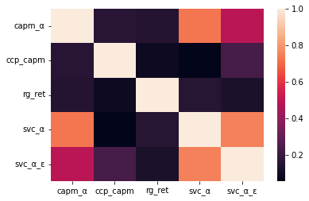

```python
all_factors = {

'capm_α' : all_fund_capm_α,
'svc_α' : all_fund_svc_α, #
# 'capm_α' : all_fund_capm_α_ε,
'svc_α_ε' : all_fund_svc_α_ε, #
# 'capm_α' : industry_concentration,
# 'capm_α' : active_share,
'ccp_capm' : ccp_capm_it,
# 'capm_α' : ccp_svc_it,
'rg_ret' : rg_ret_t,

}

c_factor_index = list((permutations(all_factors.keys(), 2)))

corrs = pd.Series(index=pd.MultiIndex.from_tuples(c_factor_index), dtype=object)
for keys in c_factor_index:
    corrs.loc[keys[0], keys[1]] = all_factors[keys[0]].corrwith(all_factors[keys[1]]).mean()

display(corrs)
sns.heatmap(corrs.unstack().fillna(1))
```

|  | monthly sharpe | β | monthly α | annual α | 6 month MDD | win rate | 5% ES | compounded annual return | excess compounded annual return | last month | last 3 months | last 6 months | cumulative all | past year | past 3 year p.a. | past 5 year p.a. | past 10 year p.a. |
| --- | --- | --- | --- | --- | --- | --- | --- | --- | --- | --- | --- | --- | --- | --- | --- | --- | --- |
| baseline | 0.088394 | 1.000000 | 0.0% | 0.0% | -102.03% | 0.0% | -19.01% | 7.13% | 4.7% | -3.42% | -12.02% | -2.01% | 307.79% | -19.59% | 2.9% | -0.7% | 23.02% |
| top 1 fund(s) | 0.156972 | 0.854764 | 0.74% | 9.22% | -92.75% | 52.28% | -17.79% | 14.77% | 12.25% | -0.17% | -10.65% | 6.94% | 959.31% | -19.03% | 24.33% | 25.52% | 59.44% |
| top 3 fund(s) | 0.138978 | 0.898075 | 0.54% | 6.65% | -87.03% | 54.82% | -18.28% | 12.58% | 10.11% | -4.07% | -14.52% | -9.11% | 699.72% | -35.34% | 14.37% | 16.23% | 38.08% |
| top 5 fund(s) | 0.171501 | 0.893852 | 0.78% | 9.71% | -73.01% | 58.38% | -17.78% | 15.95% | 13.43% | -3.53% | -13.56% | -3.99% | 1135.85% | -30.35% | 17.04% | 26.54% | 64.88% |
| top 10 fund(s) | 0.144044 | 0.886112 | 0.53% | 6.6% | -76.46% | 53.3% | -17.69% | 12.81% | 10.33% | -4.62% | -13.88% | 1.67% | 722.87% | -27.02% | 16.64% | 23.93% | 49.32% |

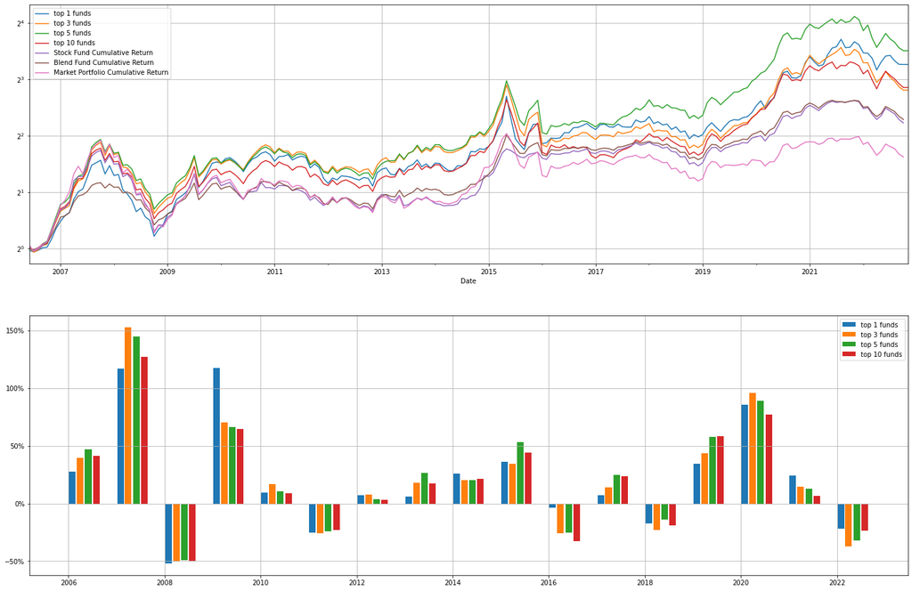

```python
all_05 = test_factors(all_factors, start_time = '2005-06', end_time = datetime.datetime.today().strftime('%Y-%m-%d'),\
     truncate_proportion = .01, MIN_VALID_NUM = 15, ivol_truncate = .2, mkt_truncate = .2, return_truncate = .01, mdd_month = 6, es_proportion = .05)
```